# Analisis Unsupervised Learning dan Clustering pada Dataset MHEALTH

Optimasi Data Time-Series Sensor dengan Windowing, Ekstraksi Fitur, PCA, Clustering, dan Validasi

Razan Nur Muhammad Ihsan 3338240032

04 June 2026

# 1 Load Library

Bagian ini memuat library yang digunakan dalam analisis. Dataset MHEALTH memiliki ukuran besar karena berupa data sensor time-series, sehingga pembacaan data menggunakan `data.table::fread()` agar lebih cepat dan hemat memori.

```r
required_packages <- c(
  "data.table",   # membaca dan memproses data besar
  "dplyr",        # manipulasi data
  "ggplot2",      # visualisasi
  "cluster",      # PAM dan silhouette
  "factoextra",   # visualisasi cluster
  "mclust",       # Gaussian Mixture Model dan ARI
  "dbscan",       # DBSCAN dan kNN distance plot
  "clusterCrit",  # Rand Index
  "clue",         # Hungarian matching untuk akurasi cluster
  "fpc",          # cluster.stats
  "clusterSim",   # Davies-Bouldin Index
  "knitr",        # tabel laporan
  "scales"        # format angka
)

installed <- rownames(installed.packages())
missing_packages <- setdiff(required_packages, installed)

if (length(missing_packages) > 0) {
  install.packages(missing_packages)
}

invisible(lapply(required_packages, library, character.only = TRUE))
```

# 2 Deskripsi Dataset

Dataset yang digunakan adalah **MHEALTH (Mobile Health)**. Dataset ini berisi rekaman sensor gerak dan tanda vital dari beberapa subjek saat melakukan aktivitas fisik. Setiap baris pada data asli bukan merepresentasikan satu responden, tetapi satu titik waktu pengukuran sensor. Karena itu, dataset ini tidak boleh langsung diperlakukan seperti data tabular biasa.

Dalam analisis ini, baris sensor mentah akan diubah menjadi fitur ringkasan berbasis window waktu. Setiap window merepresentasikan potongan aktivitas dalam durasi tertentu.

```r
# PARAMETER UTAMA ANALISIS

# Letakkan file CSV di folder kerja RStudio yang sama dengan Rmd ini.
data_file <- "mhealth_combined_10_subjects.csv"

# MHEALTH direkam pada 50 Hz, artinya sekitar 50 observasi per detik.
sampling_rate <- 50

# Window 2 detik = 100 baris per subjek.
# Jika komputer berat, naikkan menjadi 5 detik.
window_seconds <- 2
window_size_rows <- sampling_rate * window_seconds

# Label 0 adalah null class. Untuk clustering aktivitas utama, biasanya dikeluarkan.
# Jika ingin semua data termasuk label 0, ubah menjadi FALSE.
remove_null_activity <- TRUE

# Jumlah aktivitas utama pada MHEALTH adalah 12.
# Nilai ini hanya dipakai sebagai referensi pembanding/validasi, bukan sebagai variabel input clustering.
k_reference <- 12

# Strategi jumlah cluster:
# "reference"   = menggunakan k_reference = 12 agar hasil cluster dapat dibandingkan dengan 12 aktivitas.
# "silhouette"  = menggunakan k terbaik dari silhouette method.
k_strategy <- "reference"

# Batas jumlah data untuk metode yang membutuhkan matriks jarak.
# Jangan terlalu besar karena dist() bersifat memory-intensive.
max_distance_rows <- 3000
max_hclust_rows <- 3000
max_pam_rows <- 5000
max_gmm_rows <- 7000
max_internal_validation_rows <- 5000

# PCA
pca_variance_target <- 0.90
max_pcs <- 20

# DBSCAN
min_pts_dbscan <- 5
eps_quantile <- 0.90

# Gap statistic sangat berat. Aktifkan hanya jika komputer kuat.
run_gap_statistic <- FALSE
```

```r
# Deteksi file CSV secara fleksibel agar tetap berjalan bila nama file berubah,
# misalnya menjadi mhealth_combined_10_subjects(1).csv setelah download ulang.
if (!file.exists(data_file)) {
  candidate_files <- list.files(pattern = "^mhealth_combined_10_subjects.*\\.csv$", ignore.case = TRUE)
  if (length(candidate_files) > 0) {
    data_file <- candidate_files[1]
    cat("File utama tidak ditemukan. Menggunakan file:", data_file, "\n")
  } else {
    stop(paste0("File '", data_file, "' tidak ditemukan. Letakkan CSV di working directory RStudio."))
  }
}

mhealth_raw <- data.table::fread(data_file)

cat("Dimensi data mentah:", nrow(mhealth_raw), "baris x", ncol(mhealth_raw), "kolom\n")
```

```
## Dimensi data mentah: 1215745 baris x 25 kolom
```

```r
cat("Ukuran objek di memori:", format(object.size(mhealth_raw), units = "MB"), "\n")
```

```
## Ukuran objek di memori: 222.6 Mb
```

```r
knitr::kable(
  head(mhealth_raw, 5),
  caption = "Lima Baris Pertama Dataset MHEALTH"
)
```

Lima Baris Pertama Dataset MHEALTH

| subject_id | chest_acc_X | chest_acc_Y | chest_acc_Z | ECG_1 | ECG_2 | left_ankle_acc_X | left_ankle_acc_Y | left_ankle_acc_Z | left_ankle_gyro_X | left_ankle_gyro_Y | left_ankle_gyro_Z | left_ankle_mag_X | left_ankle_mag_Y | left_ankle_mag_Z | right_arm_acc_X | right_arm_acc_Y | right_arm_acc_Z | right_arm_gyro_X | right_arm_gyro_Y | right_arm_gyro_Z | right_arm_mag_X | right_arm_mag_Y | right_arm_mag_Z | activity_label |
| --- | --- | --- | --- | --- | --- | --- | --- | --- | --- | --- | --- | --- | --- | --- | --- | --- | --- | --- | --- | --- | --- | --- | --- | --- |
| 1 | -9.8184 | 0.009971 | 0.29563 | 0.0041863 | 0.0041863 | 2.1849 | -9.6967 | 0.63077 | 0.103900 | -0.84053 | -0.68762 | -0.370000 | -0.36327 | 0.29963 | -8.6499 | -4.5781 | 0.187760 | -0.44902 | -1.0103 | 0.034483 | -2.35000 | -1.6102000 | -0.030899 | 0 |
| 1 | -9.8489 | 0.524040 | 0.37348 | 0.0041863 | 0.0167450 | 2.3876 | -9.5080 | 0.68389 | 0.085343 | -0.83865 | -0.68369 | -0.197990 | -0.18151 | 0.58298 | -8.6275 | -4.3198 | 0.023595 | -0.44902 | -1.0103 | 0.034483 | -2.16320 | -0.8825400 | 0.326570 | 0 |
| 1 | -9.6602 | 0.181850 | 0.43742 | 0.0167450 | 0.0376770 | 2.4086 | -9.5674 | 0.68113 | 0.085343 | -0.83865 | -0.68369 | -0.374170 | 0.18723 | 0.43851 | -8.5055 | -4.2772 | 0.275720 | -0.44902 | -1.0103 | 0.034483 | -1.61750 | -0.1656200 | -0.030693 | 0 |
| 1 | -9.6507 | 0.214220 | 0.24033 | 0.0795400 | 0.1172200 | 2.1814 | -9.4301 | 0.55031 | 0.085343 | -0.83865 | -0.68369 | -0.017271 | 0.18366 | 0.57571 | -8.6279 | -4.3163 | 0.367520 | -0.45686 | -1.0082 | 0.025862 | -1.07710 | 0.0069451 | -0.382620 | 0 |
| 1 | -9.7030 | 0.303890 | 0.31156 | 0.2218700 | 0.2051300 | 2.4173 | -9.3889 | 0.71098 | 0.085343 | -0.83865 | -0.68369 | -0.374390 | -0.54671 | 0.44586 | -8.7008 | -4.1459 | 0.407290 | -0.45686 | -1.0082 | 0.025862 | -0.53684 | 0.1759000 | -1.095500 | 0 |

```r
# Mapping label aktivitas berdasarkan dokumentasi MHEALTH.
activity_map <- data.table(
  activity_label = 0:12,
  activity_name = c(
    "Null class",
    "Standing still",
    "Sitting and relaxing",
    "Lying down",
    "Walking",
    "Climbing stairs",
    "Waist bends forward",
    "Frontal elevation of arms",
    "Knees bending/crouching",
    "Cycling",
    "Jogging",
    "Running",
    "Jump front and back"
  )
)

sensor_cols <- setdiff(names(mhealth_raw), c("subject_id", "activity_label"))

summary_dataset <- data.frame(
  Komponen = c(
    "Jumlah baris mentah",
    "Jumlah kolom",
    "Jumlah subjek",
    "Jumlah kolom sensor",
    "Sampling rate",
    "Ukuran window",
    "Label aktivitas unik"
  ),
  Nilai = c(
    scales::comma(nrow(mhealth_raw)),
    ncol(mhealth_raw),
    length(unique(mhealth_raw$subject_id)),
    length(sensor_cols),
    paste0(sampling_rate, " Hz"),
    paste0(window_seconds, " detik (", window_size_rows, " baris)"),
    paste(sort(unique(mhealth_raw$activity_label)), collapse = ", ")
  )
)

knitr::kable(summary_dataset, caption = "Ringkasan Dataset MHEALTH")
```

Ringkasan Dataset MHEALTH

| Komponen | Nilai |
| --- | --- |
| Jumlah baris mentah | 1,215,745 |
| Jumlah kolom | 25 |
| Jumlah subjek | 10 |
| Jumlah kolom sensor | 23 |
| Sampling rate | 50 Hz |
| Ukuran window | 2 detik (100 baris) |
| Label aktivitas unik | 0, 1, 2, 3, 4, 5, 6, 7, 8, 9, 10, 11, 12 |

```r
knitr::kable(activity_map, caption = "Kode Label Aktivitas MHEALTH")
```

Kode Label Aktivitas MHEALTH

| activity_label | activity_name |
| --- | --- |
| 0 | Null class |
| 1 | Standing still |
| 2 | Sitting and relaxing |
| 3 | Lying down |
| 4 | Walking |
| 5 | Climbing stairs |
| 6 | Waist bends forward |
| 7 | Frontal elevation of arms |
| 8 | Knees bending/crouching |
| 9 | Cycling |
| 10 | Jogging |
| 11 | Running |
| 12 | Jump front and back |

# 3 Seleksi Variabel

Variabel yang dipakai untuk clustering adalah kolom sensor numerik. Kolom `subject_id` tidak digunakan sebagai fitur clustering karena hanya menunjukkan identitas subjek. Kolom `activity_label` juga tidak digunakan dalam proses clustering karena clustering bersifat unsupervised. Label aktivitas hanya digunakan setelah clustering untuk validasi eksternal.

```r
# Pastikan tipe data benar
mhealth_raw[, subject_id := as.factor(subject_id)]
mhealth_raw[, activity_label := as.integer(activity_label)]

# Filter null class jika diperlukan.
if (remove_null_activity) {
  mhealth <- mhealth_raw[activity_label != 0]
} else {
  mhealth <- copy(mhealth_raw)
}

cat("Dimensi setelah filter label 0:", nrow(mhealth), "baris x", ncol(mhealth), "kolom\n")
```

```
## Dimensi setelah filter label 0: 343195 baris x 25 kolom
```

```r
sensor_info <- data.frame(
  No = seq_along(sensor_cols),
  Sensor = sensor_cols
)

knitr::kable(sensor_info, caption = "Variabel Sensor yang Digunakan sebagai Input Clustering")
```

Variabel Sensor yang Digunakan sebagai Input Clustering

| No | Sensor |
| --- | --- |
| 1 | chest_acc_X |
| 2 | chest_acc_Y |
| 3 | chest_acc_Z |
| 4 | ECG_1 |
| 5 | ECG_2 |
| 6 | left_ankle_acc_X |
| 7 | left_ankle_acc_Y |
| 8 | left_ankle_acc_Z |
| 9 | left_ankle_gyro_X |
| 10 | left_ankle_gyro_Y |
| 11 | left_ankle_gyro_Z |
| 12 | left_ankle_mag_X |
| 13 | left_ankle_mag_Y |
| 14 | left_ankle_mag_Z |
| 15 | right_arm_acc_X |
| 16 | right_arm_acc_Y |
| 17 | right_arm_acc_Z |
| 18 | right_arm_gyro_X |
| 19 | right_arm_gyro_Y |
| 20 | right_arm_gyro_Z |
| 21 | right_arm_mag_X |
| 22 | right_arm_mag_Y |
| 23 | right_arm_mag_Z |

# 4 Eksplorasi Data (EDA)

EDA dilakukan untuk memahami distribusi data, mengecek missing value, melihat distribusi aktivitas, dan memeriksa karakteristik sensor. Karena data mentah sangat besar, beberapa visualisasi menggunakan sampel agar proses tetap ringan.

## 4.1 Missing Value

```r
missing_summary <- data.frame(
  Kolom = names(mhealth),
  Missing = colSums(is.na(mhealth)),
  Persentase = round(colSums(is.na(mhealth)) / nrow(mhealth) * 100, 4)
)

knitr::kable(
  missing_summary,
  caption = "Ringkasan Missing Value per Kolom"
)
```

Ringkasan Missing Value per Kolom

|  | Kolom | Missing | Persentase |
| --- | --- | --- | --- |
| subject_id | subject_id | 0 | 0 |
| chest_acc_X | chest_acc_X | 0 | 0 |
| chest_acc_Y | chest_acc_Y | 0 | 0 |
| chest_acc_Z | chest_acc_Z | 0 | 0 |
| ECG_1 | ECG_1 | 0 | 0 |
| ECG_2 | ECG_2 | 0 | 0 |
| left_ankle_acc_X | left_ankle_acc_X | 0 | 0 |
| left_ankle_acc_Y | left_ankle_acc_Y | 0 | 0 |
| left_ankle_acc_Z | left_ankle_acc_Z | 0 | 0 |
| left_ankle_gyro_X | left_ankle_gyro_X | 0 | 0 |
| left_ankle_gyro_Y | left_ankle_gyro_Y | 0 | 0 |
| left_ankle_gyro_Z | left_ankle_gyro_Z | 0 | 0 |
| left_ankle_mag_X | left_ankle_mag_X | 0 | 0 |
| left_ankle_mag_Y | left_ankle_mag_Y | 0 | 0 |
| left_ankle_mag_Z | left_ankle_mag_Z | 0 | 0 |
| right_arm_acc_X | right_arm_acc_X | 0 | 0 |
| right_arm_acc_Y | right_arm_acc_Y | 0 | 0 |
| right_arm_acc_Z | right_arm_acc_Z | 0 | 0 |
| right_arm_gyro_X | right_arm_gyro_X | 0 | 0 |
| right_arm_gyro_Y | right_arm_gyro_Y | 0 | 0 |
| right_arm_gyro_Z | right_arm_gyro_Z | 0 | 0 |
| right_arm_mag_X | right_arm_mag_X | 0 | 0 |
| right_arm_mag_Y | right_arm_mag_Y | 0 | 0 |
| right_arm_mag_Z | right_arm_mag_Z | 0 | 0 |
| activity_label | activity_label | 0 | 0 |

```r
cat("Total missing value:", sum(is.na(mhealth)), "\n")
```

```
## Total missing value: 0
```

**Interpretasi:** Tidak ditemukan missing value pada data yang dianalisis. Kondisi ini baik karena proses standarisasi, PCA, dan clustering dapat dilakukan tanpa imputasi pada data mentah. Walaupun demikian, pengecekan missing value tetap penting karena algoritma seperti K-Means, GMM, PAM, dan DBSCAN tidak dapat bekerja baik jika masih terdapat nilai kosong.

## 4.2 Distribusi Aktivitas

```r
activity_dist <- as.data.table(table(mhealth$activity_label))
setnames(activity_dist, c("activity_label", "N"))
activity_dist[, activity_label := as.integer(as.character(activity_label))]
activity_dist <- merge(activity_dist, activity_map, by = "activity_label", all.x = TRUE)
activity_dist[, Persentase := round(N / sum(N) * 100, 2)]

knitr::kable(
  activity_dist[order(activity_label)],
  caption = "Distribusi Aktivitas pada Data yang Dianalisis",
  format.args = list(big.mark = ",")
)
```

Distribusi Aktivitas pada Data yang Dianalisis

| activity_label | N | activity_name | Persentase |
| --- | --- | --- | --- |
| 1 | 30,720 | Standing still | 8.95 |
| 2 | 30,720 | Sitting and relaxing | 8.95 |
| 3 | 30,720 | Lying down | 8.95 |
| 4 | 30,720 | Walking | 8.95 |
| 5 | 30,720 | Climbing stairs | 8.95 |
| 6 | 28,315 | Waist bends forward | 8.25 |
| 7 | 29,441 | Frontal elevation of arms | 8.58 |
| 8 | 29,337 | Knees bending/crouching | 8.55 |
| 9 | 30,720 | Cycling | 8.95 |
| 10 | 30,720 | Jogging | 8.95 |
| 11 | 30,720 | Running | 8.95 |
| 12 | 10,342 | Jump front and back | 3.01 |

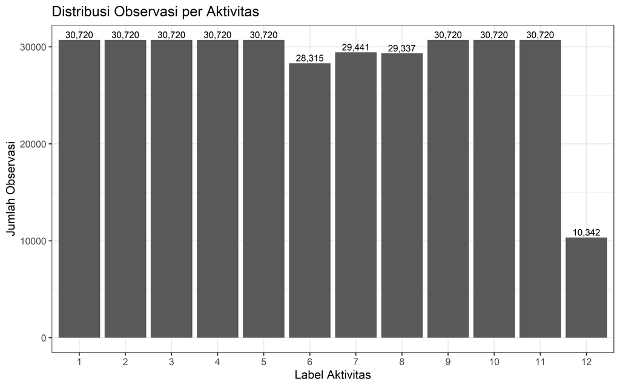

```r
ggplot(activity_dist, aes(x = factor(activity_label), y = N)) +
  geom_col() +
  geom_text(aes(label = scales::comma(N)), vjust = -0.3, size = 3) +
  labs(
    title = "Distribusi Observasi per Aktivitas",
    x = "Label Aktivitas",
    y = "Jumlah Observasi"
  ) +
  theme_bw()
```

**Interpretasi:** Distribusi aktivitas digunakan sebagai pembanding eksternal setelah clustering selesai. Aktivitas dengan observasi terbanyak adalah **Standing still** sebanyak **30,720** observasi, sedangkan yang paling sedikit adalah **Jump front and back** sebanyak **10,342** observasi. Perbedaannya cukup besar, sehingga hasil clustering berpotensi lebih mudah membentuk cluster untuk aktivitas yang dominan dan lebih sulit menangkap aktivitas yang jumlahnya kecil.

## 4.3 Statistik Deskriptif Sensor

```r
# Versi aman: tidak menggunakan t() atau data.table::transpose().
# Cara sebelumnya bisa gagal karena hasil lapply(.SD, ...) berupa list/matrix
# yang bentuk dimensinya tidak selalu konsisten saat di-knit.
sensor_summary_t <- data.table::rbindlist(lapply(sensor_cols, function(col) {
  x <- mhealth[[col]]
  data.table::data.table(
    Sensor = col,
    mean = mean(x, na.rm = TRUE),
    sd = sd(x, na.rm = TRUE),
    min = min(x, na.rm = TRUE),
    median = median(x, na.rm = TRUE),
    max = max(x, na.rm = TRUE)
  )
}))

knitr::kable(
  sensor_summary_t,
  digits = 4,
  caption = "Statistik Deskriptif Kolom Sensor"
)
```

Statistik Deskriptif Kolom Sensor

| Sensor | mean | sd | min | median | max |
| --- | --- | --- | --- | --- | --- |
| chest_acc_X | -7.4853 | 5.7019 | -22.4380 | -8.8003 | 19.0940 |
| chest_acc_Y | -0.1409 | 2.7994 | -20.1880 | -0.2926 | 20.9270 |
| chest_acc_Z | -0.9384 | 4.6112 | -18.4010 | -0.8811 | 26.1960 |
| ECG_1 | 0.0036 | 0.8391 | -8.6196 | -0.0712 | 8.5065 |
| ECG_2 | -0.0080 | 0.8577 | -8.6196 | -0.0460 | 8.5191 |
| left_ankle_acc_X | 1.8052 | 4.2142 | -22.1460 | 1.3725 | 20.0240 |
| left_ankle_acc_Y | -9.0615 | 5.2004 | -19.6190 | -9.5977 | 21.1610 |
| left_ankle_acc_Z | -0.7020 | 6.4576 | -19.3730 | 0.3401 | 25.0150 |
| left_ankle_gyro_X | 0.1012 | 0.4589 | -1.7792 | 0.2041 | 1.7106 |
| left_ankle_gyro_Y | -0.5499 | 0.4347 | -2.6604 | -0.6886 | 1.7523 |
| left_ankle_gyro_Z | -0.1211 | 0.5559 | -2.6267 | -0.0982 | 1.5815 |
| left_ankle_mag_X | 0.3276 | 76.4628 | -357.5600 | 0.1808 | 339.2200 |
| left_ankle_mag_Y | -1.8347 | 47.4302 | -364.5700 | 0.5466 | 336.2400 |
| left_ankle_mag_Z | -0.3800 | 18.8985 | -282.3900 | -0.3033 | 272.5600 |
| right_arm_acc_X | -3.4482 | 5.8916 | -22.3450 | -2.4800 | 19.8010 |
| right_arm_acc_Y | -5.7814 | 6.5784 | -18.9720 | -7.7389 | 21.9650 |
| right_arm_acc_Z | 2.3812 | 4.1780 | -18.2380 | 1.8191 | 25.7410 |
| right_arm_gyro_X | -0.2016 | 0.5495 | -1.1706 | -0.3000 | 1.4157 |
| right_arm_gyro_Y | -0.4105 | 0.5464 | -2.2567 | -0.5975 | 1.1211 |
| right_arm_gyro_Z | 0.3807 | 0.5157 | -1.1142 | 0.4483 | 1.5280 |
| right_arm_mag_X | -0.5326 | 34.2163 | -319.0300 | 0.3607 | 239.6900 |
| right_arm_mag_Y | 1.4221 | 30.2853 | -358.1300 | 0.3539 | 335.2500 |
| right_arm_mag_Z | 0.0307 | 82.6630 | -702.5700 | -0.7093 | 657.1800 |

**Interpretasi:** Tabel statistik deskriptif menunjukkan karakter dasar setiap sensor sebelum diekstraksi menjadi fitur window. Sensor dengan variasi terbesar berdasarkan standar deviasi adalah **right_arm_mag_Z** dengan sd = **82.663**, sedangkan sensor yang paling stabil adalah **left_ankle_gyro_Y** dengan sd = **0.4347**. Sensor dengan rentang nilai terbesar adalah **right_arm_mag_Z**. Perbedaan variasi ini menjadi alasan utama mengapa standarisasi diperlukan sebelum menghitung jarak dan melakukan clustering.

## 4.4 Histogram dan Boxplot Sensor Sampel

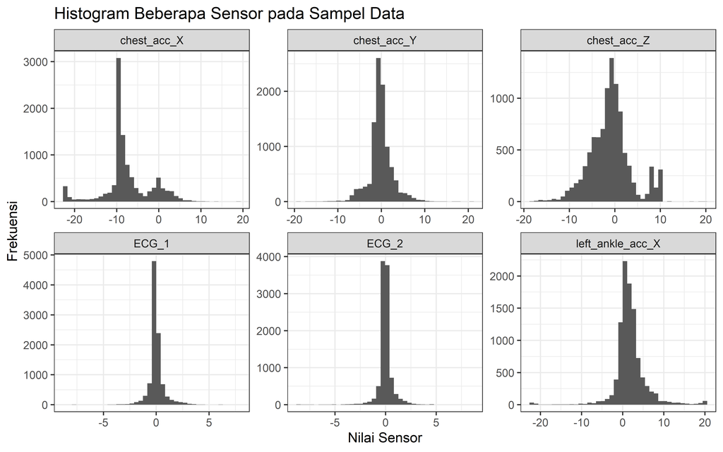

```r
set.seed(123)
eda_sample_n <- min(10000, nrow(mhealth))
eda_sample <- mhealth[sample(.N, eda_sample_n)]

sensor_plot_cols <- sensor_cols[1:min(6, length(sensor_cols))]
eda_long <- data.table::melt(
  eda_sample[, ..sensor_plot_cols],
  measure.vars = sensor_plot_cols,
  variable.name = "Sensor",
  value.name = "Nilai"
)

ggplot(eda_long, aes(x = Nilai)) +
  geom_histogram(bins = 40) +
  facet_wrap(~ Sensor, scales = "free") +
  labs(
    title = "Histogram Beberapa Sensor pada Sampel Data",
    x = "Nilai Sensor",
    y = "Frekuensi"
  ) +
  theme_bw()
```

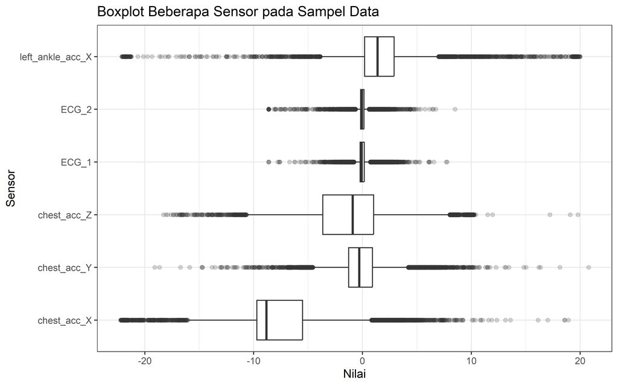

```r
ggplot(eda_long, aes(x = Sensor, y = Nilai)) +
  geom_boxplot(outlier.alpha = 0.2) +
  coord_flip() +
  labs(
    title = "Boxplot Beberapa Sensor pada Sampel Data",
    x = "Sensor",
    y = "Nilai"
  ) +
  theme_bw()
```

**Interpretasi:** Histogram memperlihatkan bentuk sebaran nilai beberapa sensor, sedangkan boxplot membantu melihat perbedaan skala, variasi, dan kemungkinan outlier. Pada data sensor gerak, nilai ekstrem tidak selalu berarti kesalahan input; nilai tersebut bisa muncul karena perubahan gerakan yang cepat, transisi aktivitas, atau perbedaan gaya bergerak antar subjek. Karena itu, data tidak langsung dibuang, tetapi diringkas melalui windowing dan distandarisasi agar pola utamanya lebih stabil untuk clustering.

# 5 Pembentukan Window dan Ekstraksi Fitur Time-Series

Dataset MHEALTH adalah data time-series sensor. Jika clustering dilakukan langsung pada 1 juta baris data mentah, hasilnya kurang stabil dan beberapa metode seperti hierarchical clustering akan gagal karena membutuhkan matriks jarak sangat besar. Oleh karena itu, data sensor diringkas per window waktu.

Pada setiap window, dihitung fitur statistik berikut:

- `mean`: rata-rata sinyal sensor
- `sd`: variasi sinyal sensor
- `min`: nilai minimum
- `max`: nilai maksimum
- `rms`: root mean square, menggambarkan energi sinyal

```r
get_mode <- function(x) {
  x <- x[!is.na(x)]
  if (length(x) == 0) return(NA_integer_)
  ux <- unique(x)
  ux[which.max(tabulate(match(x, ux)))]
}

extract_window_features <- function(dt, sensor_columns, window_size_rows) {
  dt <- copy(dt)
  dt[, row_index := seq_len(.N), by = subject_id]
  dt[, window_id := floor((row_index - 1) / window_size_rows) + 1L, by = subject_id]

  feature_dt <- dt[, c(
    list(
      n_obs = .N,
      activity_label = get_mode(activity_label)
    ),
    unlist(
      lapply(.SD, function(x) {
        list(
          mean = mean(x, na.rm = TRUE),
          sd   = sd(x, na.rm = TRUE),
          min  = min(x, na.rm = TRUE),
          max  = max(x, na.rm = TRUE),
          rms  = sqrt(mean(x^2, na.rm = TRUE))
        )
      }),
      recursive = FALSE
    )
  ), by = .(subject_id, window_id), .SDcols = sensor_columns]

  return(feature_dt)
}
```

```r
window_features <- extract_window_features(
  dt = mhealth,
  sensor_columns = sensor_cols,
  window_size_rows = window_size_rows
)

# Rapikan nama kolom agar mudah dipakai.
setnames(window_features, make.names(names(window_features), unique = TRUE))

cat("Dimensi data setelah windowing:", nrow(window_features), "baris x", ncol(window_features), "kolom\n")
```

```
## Dimensi data setelah windowing: 3437 baris x 119 kolom
```

```r
cat("Reduksi jumlah baris:", round((1 - nrow(window_features) / nrow(mhealth)) * 100, 2), "%\n")
```

```
## Reduksi jumlah baris: 99 %
```

```r
knitr::kable(
  head(window_features, 5),
  caption = "Lima Baris Pertama Data Hasil Windowing dan Ekstraksi Fitur"
)
```

Lima Baris Pertama Data Hasil Windowing dan Ekstraksi Fitur

| subject_id | window_id | n_obs | activity_label | chest_acc_X.mean | chest_acc_X.sd | chest_acc_X.min | chest_acc_X.max | chest_acc_X.rms | chest_acc_Y.mean | chest_acc_Y.sd | chest_acc_Y.min | chest_acc_Y.max | chest_acc_Y.rms | chest_acc_Z.mean | chest_acc_Z.sd | chest_acc_Z.min | chest_acc_Z.max | chest_acc_Z.rms | ECG_1.mean | ECG_1.sd | ECG_1.min | ECG_1.max | ECG_1.rms | ECG_2.mean | ECG_2.sd | ECG_2.min | ECG_2.max | ECG_2.rms | left_ankle_acc_X.mean | … |
| --- | --- | --- | --- | --- | --- | --- | --- | --- | --- | --- | --- | --- | --- | --- | --- | --- | --- | --- | --- | --- | --- | --- | --- | --- | --- | --- | --- | --- | --- | --- |
| 1 | 1 | 100 | 1 | -9.722690 | 0.1385144 | -10.0390 | -9.1065 | 9.723667 | 0.2004573 | 0.1415769 | -0.085462 | 0.69219 | 0.2450035 | 0.7971986 | 0.1535556 | 0.44857 | 1.1975 | 0.8117075 | 0.0406908 | 0.1384839 | -0.66562 | 0.74935 | 0.1436724 | -0.0257038 | 0.0991820 | -0.43119 | 0.17164 | 0.1019773 | 2.401557 | … |
| 1 | 2 | 100 | 1 | -9.761108 | 0.1398194 | -10.1170 | -9.3725 | 9.762099 | 0.2325038 | 0.1408687 | -0.165120 | 0.58919 | 0.2714840 | 0.8672433 | 0.1629634 | 0.45475 | 1.3479 | 0.8822712 | 0.0605337 | 0.1475268 | -0.44793 | 0.73679 | 0.1587792 | 0.0300994 | 0.1078810 | -0.42282 | 0.28048 | 0.1114805 | 2.364802 | … |
| 1 | 3 | 100 | 1 | -9.729408 | 0.1275357 | -9.9964 | -9.3312 | 9.730235 | 0.2028619 | 0.1466170 | -0.114710 | 0.60054 | 0.2498690 | 0.8429926 | 0.1322348 | 0.45740 | 1.1130 | 0.8531985 | 0.0351649 | 0.1481133 | -0.65725 | 0.79540 | 0.1515082 | -0.0298899 | 0.1084779 | -0.30560 | 0.23443 | 0.1119963 | 2.404739 | … |
| 1 | 4 | 100 | 1 | -9.750374 | 0.1264957 | -10.0330 | -9.3337 | 9.751186 | 0.2406337 | 0.1440341 | -0.051277 | 0.75182 | 0.2800767 | 0.7821841 | 0.1211495 | 0.45013 | 1.0372 | 0.7914180 | 0.1712190 | 0.1357497 | -0.36421 | 0.76609 | 0.2180817 | 0.1098906 | 0.1061524 | -0.19676 | 0.36421 | 0.1524191 | 2.408503 | … |
| 1 | 5 | 100 | 1 | -9.755023 | 0.1195205 | -10.0880 | -9.4584 | 9.755748 | 0.2769913 | 0.1342320 | -0.054396 | 0.61930 | 0.3075097 | 0.7781925 | 0.1460601 | 0.30473 | 1.0386 | 0.7916462 | 0.0555522 | 0.1567667 | -0.53585 | 0.86238 | 0.1655780 | 0.0180010 | 0.0997165 | -0.38932 | 0.22187 | 0.1008364 | 2.392388 | … |

**Interpretasi:** Proses windowing mengubah data dari **343,195** baris sensor mentah menjadi **3,437** baris window, atau berkurang sekitar **99%**. Pengurangan ini penting karena metode berbasis jarak tidak realistis dijalankan langsung pada jutaan titik waktu. Setiap baris window sekarang mewakili ringkasan pola sensor selama sekitar **2 detik**, bukan hanya satu titik pengukuran.

# 6 Standarisasi Data

Karena sensor memiliki skala dan satuan yang berbeda, seluruh fitur numerik harus distandarisasi menggunakan z-score. Standarisasi dilakukan setelah ekstraksi fitur, bukan pada data mentah, agar ukuran data lebih efisien.

```r
id_cols <- c("subject_id", "window_id", "n_obs", "activity_label")
feature_cols <- setdiff(names(window_features), id_cols)

# Ganti nilai infinite menjadi NA, lalu imputasi dengan median.
for (col in feature_cols) {
  set(window_features, which(!is.finite(window_features[[col]])), col, NA_real_)
  med <- median(window_features[[col]], na.rm = TRUE)
  if (is.na(med)) med <- 0
  set(window_features, which(is.na(window_features[[col]])), col, med)
}

feature_matrix <- as.matrix(window_features[, ..feature_cols])
feature_scaled <- scale(feature_matrix)
feature_scaled[is.na(feature_scaled)] <- 0

cat("Dimensi feature matrix setelah scaling:", nrow(feature_scaled), "baris x", ncol(feature_scaled), "kolom\n")
```

```
## Dimensi feature matrix setelah scaling: 3437 baris x 115 kolom
```

**Interpretasi:** Setelah standarisasi, setiap fitur berada pada skala yang sebanding. Ini mencegah sensor dengan nilai numerik besar mendominasi perhitungan jarak. Secara praktis, K-Means, PAM, Hierarchical, dan DBSCAN akan membandingkan pola relatif antar window, bukan hanya besar kecilnya satuan sensor tertentu.

# 7 Reduksi Dimensi dengan PCA

PCA digunakan untuk mengurangi dimensi fitur, mempercepat clustering, dan mengurangi noise. Komponen utama yang dipakai adalah sejumlah komponen yang menjelaskan minimal 90% variasi data, tetapi dibatasi maksimal 20 komponen.

```r
pca_model <- prcomp(feature_scaled, center = FALSE, scale. = FALSE)
var_exp <- pca_model$sdev^2 / sum(pca_model$sdev^2)
cum_var <- cumsum(var_exp)

n_pcs <- which(cum_var >= pca_variance_target)[1]
if (is.na(n_pcs)) n_pcs <- min(max_pcs, ncol(pca_model$x))
n_pcs <- min(n_pcs, max_pcs, ncol(pca_model$x))

pca_data <- pca_model$x[, seq_len(n_pcs), drop = FALSE]

pca_summary <- data.frame(
  PC = paste0("PC", seq_along(var_exp)),
  Variance = round(var_exp * 100, 3),
  Cumulative = round(cum_var * 100, 3)
)

knitr::kable(
  head(pca_summary, max(10, n_pcs)),
  caption = "Proporsi Variansi PCA"
)
```

Proporsi Variansi PCA

| PC | Variance | Cumulative |
| --- | --- | --- |
| PC1 | 41.546 | 41.546 |
| PC2 | 10.931 | 52.476 |
| PC3 | 5.714 | 58.190 |
| PC4 | 4.817 | 63.006 |
| PC5 | 3.976 | 66.982 |
| PC6 | 3.319 | 70.301 |
| PC7 | 2.686 | 72.987 |
| PC8 | 2.046 | 75.033 |
| PC9 | 2.015 | 77.048 |
| PC10 | 1.928 | 78.976 |
| PC11 | 1.552 | 80.528 |
| PC12 | 1.506 | 82.034 |
| PC13 | 1.248 | 83.283 |
| PC14 | 1.174 | 84.456 |
| PC15 | 1.032 | 85.488 |
| PC16 | 0.946 | 86.434 |
| PC17 | 0.876 | 87.311 |
| PC18 | 0.856 | 88.166 |
| PC19 | 0.811 | 88.977 |
| PC20 | 0.685 | 89.662 |

```r
cat("Jumlah PC yang digunakan:", n_pcs, "\n")
```

```
## Jumlah PC yang digunakan: 20
```

```r
cat("Variansi kumulatif:", round(cum_var[n_pcs] * 100, 2), "%\n")
```

```
## Variansi kumulatif: 89.66 %
```

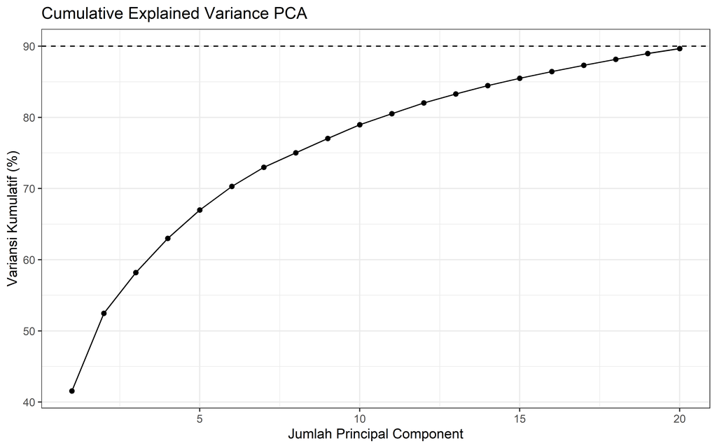

```r
ggplot(pca_summary[1:min(20, nrow(pca_summary)), ], aes(x = seq_along(Variance), y = Cumulative)) +
  geom_line() +
  geom_point() +
  geom_hline(yintercept = pca_variance_target * 100, linetype = 2) +
  labs(
    title = "Cumulative Explained Variance PCA",
    x = "Jumlah Principal Component",
    y = "Variansi Kumulatif (%)"
  ) +
  theme_bw()
```

**Interpretasi:** PCA mempertahankan **20** komponen utama dengan variansi kumulatif sekitar **89.66%**. Dua komponen pertama menjelaskan sekitar **52.48%** variasi. Jika plot PCA 2D masih menunjukkan tumpang tindih, hal itu wajar karena visualisasi hanya memakai dua dimensi, sedangkan proses clustering menggunakan hingga **20** komponen.

# 8 Perhitungan Jarak

Materi distance-based clustering menggunakan jarak, misalnya Euclidean distance, sebagai ukuran kemiripan objek. Namun, pada dataset besar, `dist()` tidak boleh dihitung pada seluruh data karena akan membentuk matriks jarak berukuran sangat besar. Oleh karena itu, perhitungan jarak hanya dilakukan pada sampel data hasil windowing.

```r
set.seed(123)
distance_idx <- sample(seq_len(nrow(pca_data)), min(max_distance_rows, nrow(pca_data)))
pca_distance_sample <- pca_data[distance_idx, , drop = FALSE]

dist_sample <- dist(pca_distance_sample, method = "euclidean")

cat("Jumlah baris untuk perhitungan jarak:", nrow(pca_distance_sample), "\n")
```

```
## Jumlah baris untuk perhitungan jarak: 3000
```

```r
cat("Ringkasan jarak Euclidean pada sampel:\n")
```

```
## Ringkasan jarak Euclidean pada sampel:
```

```r
print(summary(as.vector(dist_sample)))
```

```
##     Min.  1st Qu.   Median     Mean  3rd Qu.     Max.
##  0.05134  9.33947 12.32193 13.32158 16.46110 37.29485
```

**Interpretasi:** Ringkasan jarak Euclidean pada sampel menunjukkan seberapa jauh perbedaan pola antar window setelah scaling dan PCA. Median jarak sebesar **12.3219** dapat dianggap sebagai gambaran jarak tipikal antar window. Jarak minimum yang sangat kecil menunjukkan adanya window dengan pola sensor mirip, sedangkan jarak maksimum yang besar menunjukkan adanya window dengan pola aktivitas yang jauh berbeda.

# 9 Penentuan Jumlah Cluster Optimal

Jumlah cluster optimal ditentukan menggunakan metode internal, terutama Elbow Method dan Silhouette Method. Gap Statistic juga disediakan, tetapi secara default dimatikan karena cukup berat untuk data besar.

```r
set.seed(123)
eval_idx <- sample(seq_len(nrow(pca_data)), min(max_distance_rows, nrow(pca_data)))
pca_eval <- pca_data[eval_idx, , drop = FALSE]

dist_eval <- dist(pca_eval)

k_grid <- 2:min(15, nrow(pca_eval) - 1)

wss_values <- numeric(length(k_grid))
sil_values <- numeric(length(k_grid))

for (i in seq_along(k_grid)) {
  k <- k_grid[i]
  km_tmp <- kmeans(pca_eval, centers = k, nstart = 10, iter.max = 100)
  wss_values[i] <- km_tmp$tot.withinss
  sil_values[i] <- mean(silhouette(km_tmp$cluster, dist_eval)[, "sil_width"])
}

k_table <- data.frame(
  k = k_grid,
  WSS = wss_values,
  Avg_Silhouette = sil_values
)

k_silhouette <- k_table$k[which.max(k_table$Avg_Silhouette)]

knitr::kable(
  k_table,
  digits = 4,
  caption = "Perbandingan WSS dan Average Silhouette untuk Kandidat k"
)
```

Perbandingan WSS dan Average Silhouette untuk Kandidat k

| k | WSS | Avg_Silhouette |
| --- | --- | --- |
| 2 | 189602.12 | 0.4281 |
| 3 | 155708.94 | 0.3677 |
| 4 | 141783.95 | 0.2145 |
| 5 | 130423.69 | 0.2435 |
| 6 | 120710.00 | 0.2181 |
| 7 | 111081.82 | 0.2363 |
| 8 | 103358.50 | 0.2440 |
| 9 | 97076.13 | 0.2422 |
| 10 | 93597.87 | 0.2502 |
| 11 | 88062.07 | 0.2563 |
| 12 | 82586.60 | 0.2837 |
| 13 | 79872.41 | 0.2766 |
| 14 | 77174.52 | 0.2812 |
| 15 | 75208.35 | 0.2870 |

```r
cat("k terbaik berdasarkan Silhouette:", k_silhouette, "\n")
```

```
## k terbaik berdasarkan Silhouette: 2
```

```r
cat("k referensi berdasarkan jumlah aktivitas:", k_reference, "\n")
```

```
## k referensi berdasarkan jumlah aktivitas: 12
```

```r
if (k_strategy == "silhouette") {
  k_final <- k_silhouette
} else {
  k_final <- k_reference
}

cat("k yang digunakan untuk clustering utama:", k_final, "\n")
```

```
## k yang digunakan untuk clustering utama: 12
```

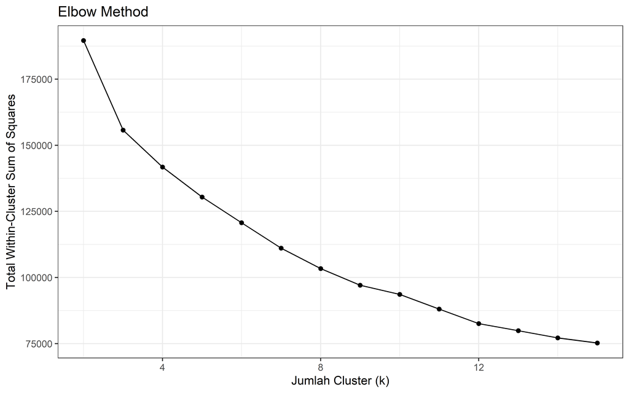

```r
ggplot(k_table, aes(x = k, y = WSS)) +
  geom_line() +
  geom_point() +
  labs(
    title = "Elbow Method",
    x = "Jumlah Cluster (k)",
    y = "Total Within-Cluster Sum of Squares"
  ) +
  theme_bw()
```

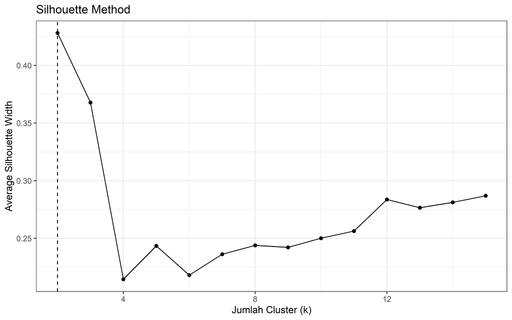

```r
ggplot(k_table, aes(x = k, y = Avg_Silhouette)) +
  geom_line() +
  geom_point() +
  geom_vline(xintercept = k_silhouette, linetype = 2) +
  labs(
    title = "Silhouette Method",
    x = "Jumlah Cluster (k)",
    y = "Average Silhouette Width"
  ) +
  theme_bw()
```

**Interpretasi:** Berdasarkan Silhouette Method, kandidat jumlah cluster terbaik adalah **k = 2** dengan average silhouette **0.4281**. Pada analisis utama digunakan **k = 12**. Nilai ini dipilih sebagai referensi karena dataset MHEALTH memiliki 12 aktivitas utama, sehingga hasil cluster lebih mudah diverifikasi terhadap label aktivitas asli. Perbedaan antara k silhouette dan k referensi perlu dibaca sebagai kompromi antara struktur data dan tujuan evaluasi.

```r
if (run_gap_statistic) {
  set.seed(123)
  gap_result <- clusGap(
    pca_eval,
    FUN = kmeans,
    K.max = min(15, nrow(pca_eval) - 1),
    B = 20,
    nstart = 10
  )
  print(gap_result)
  factoextra::fviz_gap_stat(gap_result)
} else {
  cat("Gap Statistic tidak dijalankan karena opsi run_gap_statistic = FALSE.\n")
}
```

```
## Gap Statistic tidak dijalankan karena opsi run_gap_statistic = FALSE.
```

# 10 Metode Clustering 1: K-Means

K-Means adalah algoritma partitioning clustering yang membagi data ke dalam `k` cluster dengan meminimalkan jarak objek terhadap centroid cluster. Pada data MHEALTH, K-Means dijalankan pada data PCA hasil ekstraksi fitur window.

```r
set.seed(123)
km_result <- kmeans(
  pca_data,
  centers = k_final,
  nstart = 25,
  iter.max = 300
)

window_features[, Cluster_KMeans := as.factor(km_result$cluster)]

cat("Ukuran cluster K-Means:\n")
```

```
## Ukuran cluster K-Means:
```

```r
print(table(window_features$Cluster_KMeans))
```

```
##
##   1   2   3   4   5   6   7   8   9  10  11  12
## 271 424 265 299 243 224 327 307 262 311 363 141
```

```r
cat("Total within-cluster sum of squares:", km_result$tot.withinss, "\n")
```

```
## Total within-cluster sum of squares: 95698.62
```

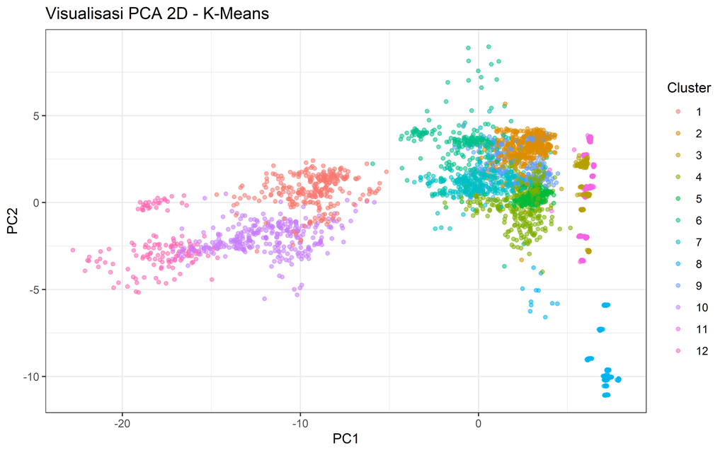

```r
pca_plot <- data.frame(
  PC1 = pca_data[, 1],
  PC2 = pca_data[, 2],
  Cluster = window_features$Cluster_KMeans,
  Activity = as.factor(window_features$activity_label)
)

ggplot(pca_plot, aes(x = PC1, y = PC2, color = Cluster)) +
  geom_point(alpha = 0.55, size = 1.2) +
  labs(
    title = "Visualisasi PCA 2D - K-Means",
    x = "PC1",
    y = "PC2",
    color = "Cluster"
  ) +
  theme_bw()
```

**Interpretasi K-Means:** Plot PCA memperlihatkan bagaimana K-Means membagi data berdasarkan kedekatan terhadap centroid. Ukuran cluster terbesar adalah **424** window dan terkecil **141** window. Ukuran cluster relatif masih seimbang, sehingga pemisahan K-Means tidak terlalu didominasi oleh satu cluster saja.

# 11 Metode Clustering 2: Gaussian Mixture Model (GMM)

GMM adalah model-based clustering yang mengasumsikan data berasal dari campuran beberapa distribusi Gaussian. Berbeda dari K-Means, GMM menghasilkan probabilitas keanggotaan cluster. Karena GMM cukup berat, model dilatih pada sampel jika jumlah window terlalu besar, lalu digunakan untuk memprediksi seluruh window.

```r
set.seed(123)
gmm_idx <- sample(seq_len(nrow(pca_data)), min(max_gmm_rows, nrow(pca_data)))
pca_gmm_train <- pca_data[gmm_idx, , drop = FALSE]

gmm_result <- Mclust(pca_gmm_train, G = k_final, verbose = FALSE)
gmm_pred <- predict(gmm_result, newdata = pca_data)

window_features[, Cluster_GMM := as.factor(gmm_pred$classification)]

cat("Model GMM terpilih:", gmm_result$modelName, "\n")
```

```
## Model GMM terpilih: VEV
```

```r
cat("Jumlah data training GMM:", nrow(pca_gmm_train), "\n")
```

```
## Jumlah data training GMM: 3437
```

```r
cat("Ukuran cluster GMM:\n")
```

```
## Ukuran cluster GMM:
```

```r
print(table(window_features$Cluster_GMM))
```

```
##
##    1    2    3    4    5    6    7    8    9   10   11   12
##  119  239 1301 1215   30   60   29  237   29  119   29   30
```

```r
summary(gmm_result)
```

```
## ----------------------------------------------------
## Gaussian finite mixture model fitted by EM algorithm
## ----------------------------------------------------
##
## Mclust VEV (ellipsoidal, equal shape) model with 12 components:
##
##  log-likelihood    n   df       BIC       ICL
##       -74466.39 3437 2562 -169793.5 -169801.2
##
## Clustering table:
##    1    2    3    4    5    6    7    8    9   10   11   12
##  119  239 1301 1215   30   60   29  237   29  119   29   30
```

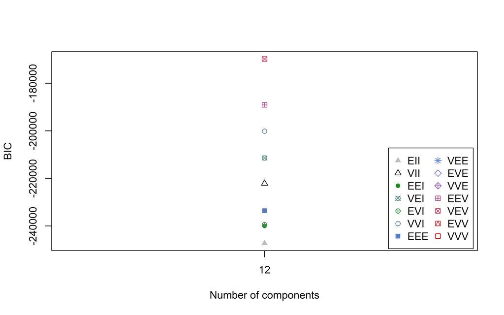

```r
plot(gmm_result, what = "BIC")
```

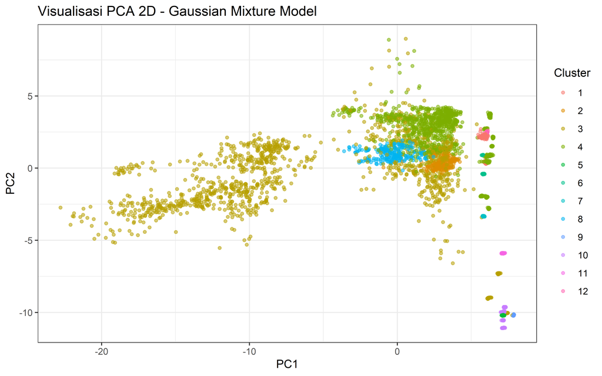

```r
pca_plot$Cluster <- window_features$Cluster_GMM

ggplot(pca_plot, aes(x = PC1, y = PC2, color = Cluster)) +
  geom_point(alpha = 0.55, size = 1.2) +
  labs(
    title = "Visualisasi PCA 2D - Gaussian Mixture Model",
    x = "PC1",
    y = "PC2",
    color = "Cluster"
  ) +
  theme_bw()
```

**Interpretasi GMM:** GMM menggunakan pendekatan probabilistik, sehingga lebih fleksibel dibanding K-Means ketika bentuk cluster tidak sepenuhnya bulat. Model yang digunakan adalah **VEV**. Jika plot GMM tampak berbeda dari K-Means, hal itu menunjukkan bahwa asumsi distribusi Gaussian dan kovarians cluster memengaruhi cara data dipisahkan. Ukuran cluster terbesar pada GMM adalah **1,301** window.

# 12 Metode Clustering 3: Hierarchical Clustering (Average Linkage)

Hierarchical clustering membutuhkan matriks jarak. Karena `dist()` pada seluruh data MHEALTH dapat menghasilkan kebutuhan memori sangat besar, hierarchical clustering hanya dilakukan pada sampel window. Hasil sampel kemudian digunakan untuk membuat centroid pendekatan, lalu seluruh data diberi cluster berdasarkan centroid terdekat. Ini adalah pendekatan praktis agar metode hierarchical tetap dapat ditampilkan sesuai materi tanpa menyebabkan error memori.

```r
set.seed(123)
hc_idx <- sample(seq_len(nrow(pca_data)), min(max_hclust_rows, nrow(pca_data)))
pca_hc_sample <- pca_data[hc_idx, , drop = FALSE]

dist_hc <- dist(pca_hc_sample, method = "euclidean")
hc_average <- hclust(dist_hc, method = "average")
hc_sample_cluster <- cutree(hc_average, k = k_final)

# Fungsi assignment ke centroid terdekat.
assign_to_centroids <- function(X, centers) {
  X <- as.matrix(X)
  centers <- as.matrix(centers)

  dist_mat <- sapply(seq_len(nrow(centers)), function(j) {
    rowSums((X - matrix(centers[j, ], nrow = nrow(X), ncol = ncol(X), byrow = TRUE))^2)
  })

  max.col(-dist_mat)
}

hc_centroids <- rowsum(pca_hc_sample, group = hc_sample_cluster) / as.vector(table(hc_sample_cluster))
hc_all_cluster <- assign_to_centroids(pca_data, hc_centroids)

window_features[, Cluster_HClust := as.factor(hc_all_cluster)]

cat("Jumlah sampel hierarchical:", nrow(pca_hc_sample), "\n")
```

```
## Jumlah sampel hierarchical: 3000
```

```r
cat("Ukuran cluster Hierarchical Approximation:\n")
```

```
## Ukuran cluster Hierarchical Approximation:
```

```r
print(table(window_features$Cluster_HClust))
```

```
##
##    1    2    3    4    5    6    7    8    9   10   11   12
##  306 2358  541   89   22    5   27   35   11   16   26    1
```

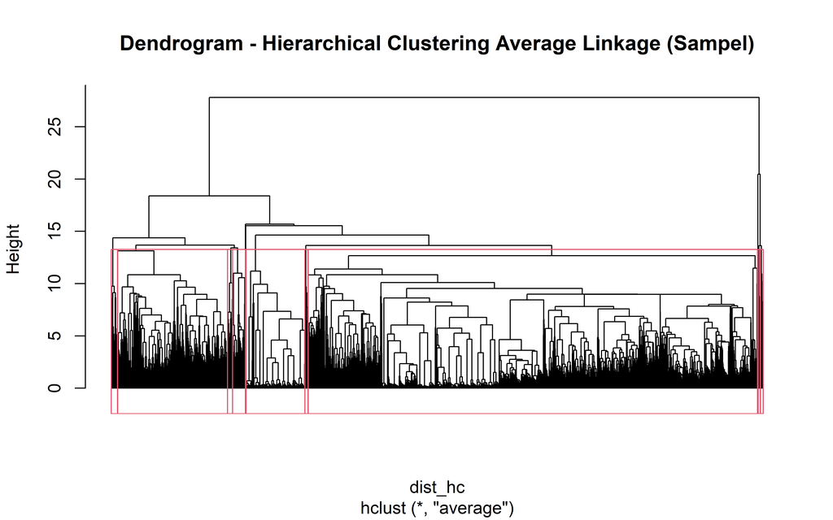

```r
plot(
  hc_average,
  labels = FALSE,
  hang = -1,
  main = "Dendrogram - Hierarchical Clustering Average Linkage (Sampel)"
)
rect.hclust(hc_average, k = k_final)
```

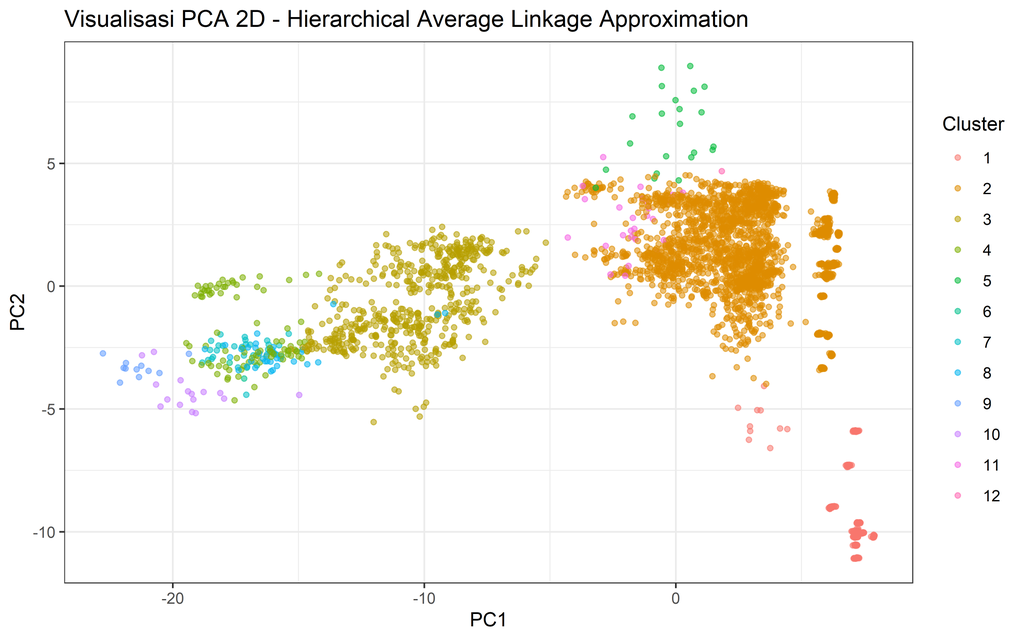

```r
pca_plot$Cluster <- window_features$Cluster_HClust

ggplot(pca_plot, aes(x = PC1, y = PC2, color = Cluster)) +
  geom_point(alpha = 0.55, size = 1.2) +
  labs(
    title = "Visualisasi PCA 2D - Hierarchical Average Linkage Approximation",
    x = "PC1",
    y = "PC2",
    color = "Cluster"
  ) +
  theme_bw()
```

**Interpretasi Hierarchical:** Dendrogram menunjukkan proses penggabungan objek dari sampel window berdasarkan average linkage. Karena data penuh terlalu besar untuk matriks jarak, hasil hierarchical digunakan sebagai pendekatan melalui sampel dan centroid. Jika beberapa cabang dendrogram bergabung pada height yang tinggi, berarti kelompok tersebut relatif berbeda dari kelompok lain. Ukuran cluster terbesar pada pendekatan hierarchical adalah **2,358** window.

# 13 Metode Clustering 4: PAM (Partition Around Medoids)

PAM atau K-Medoids mirip K-Means, tetapi pusat cluster adalah data aktual yang disebut medoid. Metode ini lebih tahan terhadap outlier, tetapi lebih berat daripada K-Means. Karena itu, PAM dilatih pada sampel, lalu seluruh window diassign ke medoid terdekat.

```r
set.seed(123)
pam_idx <- sample(seq_len(nrow(pca_data)), min(max_pam_rows, nrow(pca_data)))
pca_pam_sample <- pca_data[pam_idx, , drop = FALSE]

pam_result <- pam(pca_pam_sample, k = k_final, metric = "euclidean")

medoid_matrix <- pca_pam_sample[pam_result$id.med, , drop = FALSE]
pam_all_cluster <- assign_to_centroids(pca_data, medoid_matrix)

window_features[, Cluster_PAM := as.factor(pam_all_cluster)]

cat("Jumlah sampel PAM:", nrow(pca_pam_sample), "\n")
```

```
## Jumlah sampel PAM: 3437
```

```r
cat("Ukuran cluster PAM approximation:\n")
```

```
## Ukuran cluster PAM approximation:
```

```r
print(table(window_features$Cluster_PAM))
```

```
##
##   1   2   3   4   5   6   7   8   9  10  11  12
## 306 304 316 255 234 247 284 297 438 324 272 160
```

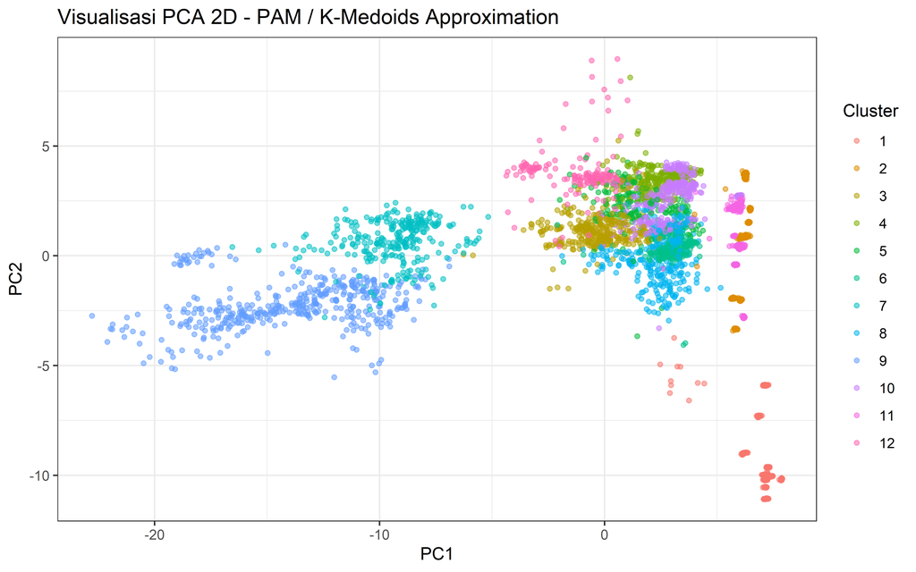

```r
pca_plot$Cluster <- window_features$Cluster_PAM

ggplot(pca_plot, aes(x = PC1, y = PC2, color = Cluster)) +
  geom_point(alpha = 0.55, size = 1.2) +
  labs(
    title = "Visualisasi PCA 2D - PAM / K-Medoids Approximation",
    x = "PC1",
    y = "PC2",
    color = "Cluster"
  ) +
  theme_bw()
```

# 14 Metode Clustering 5: DBSCAN

DBSCAN mengelompokkan data berdasarkan kepadatan. Keunggulannya adalah dapat menemukan noise/outlier dan tidak harus menentukan jumlah cluster sejak awal. Parameter pentingnya adalah `eps` dan `minPts`.

Nilai `eps` ditentukan dari k-distance plot pada sampel data. Pada script ini, `eps` awal dipilih secara otomatis dari kuantil k-distance, tetapi tetap dapat disesuaikan manual setelah melihat plot.

```r
set.seed(123)
dbscan_eps_idx <- sample(seq_len(nrow(pca_data)), min(max_distance_rows, nrow(pca_data)))
pca_dbscan_eps <- pca_data[dbscan_eps_idx, , drop = FALSE]

knn_dist <- dbscan::kNNdist(pca_dbscan_eps, k = min_pts_dbscan)
eps_opt <- as.numeric(quantile(knn_dist, probs = eps_quantile, na.rm = TRUE))

cat("minPts DBSCAN:", min_pts_dbscan, "\n")
```

```
## minPts DBSCAN: 5
```

```r
cat("eps otomatis berdasarkan kuantil", eps_quantile, ":", round(eps_opt, 4), "\n")
```

```
## eps otomatis berdasarkan kuantil 0.9 : 4.2886
```

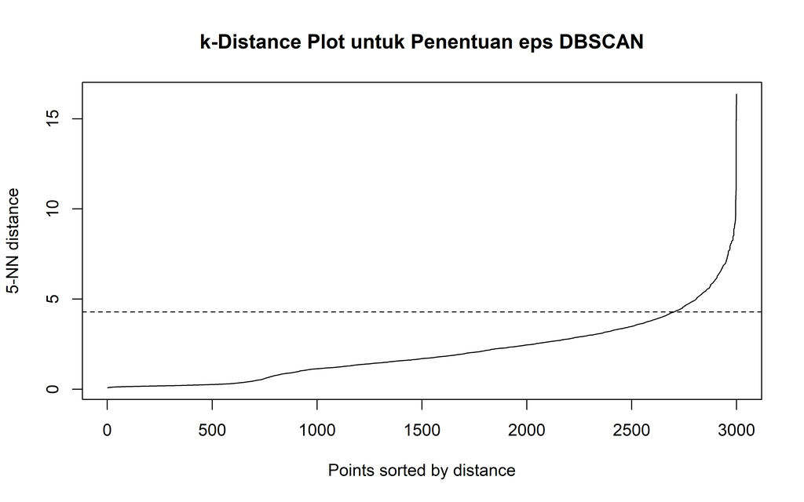

```r
dbscan::kNNdistplot(pca_dbscan_eps, k = min_pts_dbscan)
abline(h = eps_opt, lty = 2)
title("k-Distance Plot untuk Penentuan eps DBSCAN")
```

**Interpretasi k-distance plot:** Garis horizontal menunjukkan nilai eps otomatis sebesar **4.2886**. Pada DBSCAN, eps menentukan radius tetangga. Nilai eps yang terlalu kecil akan menghasilkan banyak noise, sedangkan eps terlalu besar dapat menggabungkan beberapa kelompok yang seharusnya terpisah. Karena itu, hasil DBSCAN perlu dibaca bersama jumlah noise dan visualisasi PCA.

```r
dbscan_result <- dbscan::dbscan(pca_data, eps = eps_opt, minPts = min_pts_dbscan)

window_features[, Cluster_DBSCAN := as.factor(dbscan_result$cluster)]

cat("Ukuran cluster DBSCAN, cluster 0 = noise:\n")
```

```
## Ukuran cluster DBSCAN, cluster 0 = noise:
```

```r
print(table(window_features$Cluster_DBSCAN))
```

```
##
##    0    1    2    3    4    5    6    7    8    9   10   11   12   13   14   15   16   17   18   19
##  181 1964  179  241  272    9    6   30   29  182   10   90   30   58   11   14    9   30    9   29
##   20   21   22   23
##   10    5   29   10
```

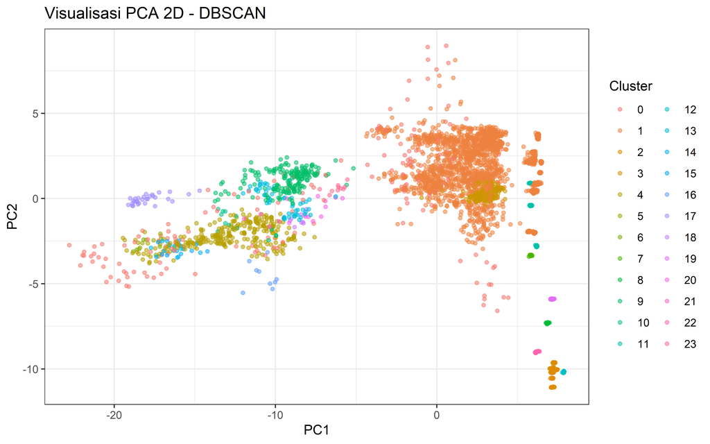

```r
pca_plot$Cluster <- window_features$Cluster_DBSCAN

ggplot(pca_plot, aes(x = PC1, y = PC2, color = Cluster)) +
  geom_point(alpha = 0.55, size = 1.2) +
  labs(
    title = "Visualisasi PCA 2D - DBSCAN",
    x = "PC1",
    y = "PC2",
    color = "Cluster"
  ) +
  theme_bw()
```

**Interpretasi DBSCAN:** DBSCAN menghasilkan **23** cluster non-noise dan **181** window noise (**5.27%**). Proporsi noise masih wajar, sehingga DBSCAN dapat digunakan sebagai pembanding untuk mendeteksi pola padat dan outlier.

# 15 Validasi Cluster

Validasi cluster dilakukan dengan dua pendekatan:

1. **External criteria**, karena dataset MHEALTH memiliki `activity_label`. Label ini tidak digunakan saat clustering, tetapi digunakan setelah clustering untuk mengecek apakah hasil cluster sejalan dengan aktivitas asli.
2. **Internal criteria**, yaitu validasi berdasarkan struktur data dan hasil cluster, seperti silhouette width, Davies-Bouldin Index, dan Calinski-Harabasz Index.

## 15.1 Fungsi Validasi Eksternal

```r
purity_score <- function(cluster, label) {
  tab <- table(cluster, label)
  sum(apply(tab, 1, max)) / sum(tab)
}

cluster_accuracy <- function(cluster, label) {
  tab <- table(cluster, label)
  mat <- as.matrix(tab)

  n <- max(nrow(mat), ncol(mat))
  square_mat <- matrix(0, nrow = n, ncol = n)
  square_mat[seq_len(nrow(mat)), seq_len(ncol(mat))] <- mat

  assignment <- clue::solve_LSAP(max(square_mat) - square_mat)
  sum(square_mat[cbind(seq_len(n), assignment)]) / sum(mat)
}

rand_index <- function(cluster, label) {
  clusterCrit::extCriteria(
    as.integer(as.factor(cluster)),
    as.integer(as.factor(label)),
    "Rand"
  )$rand
}

external_validation <- function(cluster, label, method_name) {
  keep <- !is.na(cluster) & !is.na(label)
  cluster <- cluster[keep]
  label <- label[keep]

  data.frame(
    Metode = method_name,
    Accuracy = round(cluster_accuracy(cluster, label), 4),
    Purity = round(purity_score(cluster, label), 4),
    Rand_Index = round(rand_index(cluster, label), 4),
    Adjusted_Rand_Index = round(mclust::adjustedRandIndex(cluster, label), 4)
  )
}
```

```r
true_label <- as.factor(window_features$activity_label)

validasi_external <- dplyr::bind_rows(
  external_validation(window_features$Cluster_KMeans, true_label, "K-Means"),
  external_validation(window_features$Cluster_GMM, true_label, "GMM"),
  external_validation(window_features$Cluster_HClust, true_label, "Hierarchical Average"),
  external_validation(window_features$Cluster_PAM, true_label, "PAM / K-Medoids"),
  external_validation(window_features$Cluster_DBSCAN, true_label, "DBSCAN")
)

knitr::kable(
  validasi_external,
  caption = "Validasi Eksternal terhadap Label Aktivitas Asli"
)
```

Validasi Eksternal terhadap Label Aktivitas Asli

| Metode | Accuracy | Purity | Rand_Index | Adjusted_Rand_Index |
| --- | --- | --- | --- | --- |
| K-Means | 0.6776 | 0.7105 | 0.9300 | 0.5592 |
| GMM | 0.3864 | 0.4292 | 0.7503 | 0.2159 |
| Hierarchical Average | 0.3000 | 0.3328 | 0.5644 | 0.1349 |
| PAM / K-Medoids | 0.6514 | 0.6904 | 0.9305 | 0.5607 |
| DBSCAN | 0.3538 | 0.4463 | 0.6865 | 0.1610 |

**Interpretasi validasi eksternal:** ARI, Rand Index, accuracy, dan purity membandingkan cluster dengan label aktivitas asli. Metode dengan Adjusted Rand Index tertinggi adalah **PAM / K-Medoids** dengan ARI = **0.5607**. Metode dengan purity tertinggi adalah **K-Means** dengan purity = **0.7105**. Nilai ini tidak digunakan untuk membentuk cluster, tetapi membantu mengecek apakah pola cluster sejalan dengan aktivitas fisik sebenarnya.

## 15.2 Fungsi Validasi Internal

Validasi internal menggunakan sampel karena membutuhkan matriks jarak. Noise DBSCAN (`cluster = 0`) dikeluarkan dari perhitungan internal.

```r
validate_internal <- function(cluster_label, method_name, exclude_noise = FALSE) {
  label <- as.character(cluster_label)
  idx <- sample(seq_len(nrow(pca_data)), min(max_internal_validation_rows, nrow(pca_data)))

  if (exclude_noise) {
    idx <- idx[label[idx] != "0"]
  }

  label_keep <- label[idx]
  valid <- !is.na(label_keep)
  idx <- idx[valid]
  label_keep <- label_keep[valid]

  if (length(unique(label_keep)) < 2 || length(label_keep) < 3) {
    return(data.frame(
      Metode = method_name,
      N = length(label_keep),
      Jumlah_Cluster = length(unique(label_keep)),
      Noise = sum(label == "0", na.rm = TRUE),
      Silhouette = NA,
      Davies_Bouldin = NA,
      Calinski_Harabasz = NA
    ))
  }

  x <- pca_data[idx, , drop = FALSE]
  y <- as.integer(as.factor(label_keep))
  d <- dist(x)

  sil <- mean(cluster::silhouette(y, d)[, "sil_width"])
  st <- fpc::cluster.stats(d, y)
  db <- tryCatch(clusterSim::index.DB(x, y)$DB, error = function(e) NA)

  data.frame(
    Metode = method_name,
    N = length(label_keep),
    Jumlah_Cluster = length(unique(label_keep)),
    Noise = sum(label == "0", na.rm = TRUE),
    Silhouette = round(sil, 4),
    Davies_Bouldin = round(db, 4),
    Calinski_Harabasz = round(st$ch, 2)
  )
}
```

```r
set.seed(123)
validasi_internal <- dplyr::bind_rows(
  validate_internal(window_features$Cluster_KMeans, "K-Means"),
  validate_internal(window_features$Cluster_GMM, "GMM"),
  validate_internal(window_features$Cluster_HClust, "Hierarchical Average"),
  validate_internal(window_features$Cluster_PAM, "PAM / K-Medoids"),
  validate_internal(window_features$Cluster_DBSCAN, "DBSCAN", exclude_noise = TRUE)
)

validasi_internal_ranked <- validasi_internal %>%
  mutate(
    Rank_Silhouette = ifelse(is.na(Silhouette), Inf, rank(-Silhouette, ties.method = "min")),
    Rank_DB = ifelse(is.na(Davies_Bouldin), Inf, rank(Davies_Bouldin, ties.method = "min")),
    Rank_CH = ifelse(is.na(Calinski_Harabasz), Inf, rank(-Calinski_Harabasz, ties.method = "min")),
    Rank_Total = Rank_Silhouette + Rank_DB + Rank_CH
  ) %>%
  arrange(Rank_Total, desc(Silhouette), Davies_Bouldin, desc(Calinski_Harabasz))

knitr::kable(
  validasi_internal_ranked,
  caption = "Validasi Internal Semua Algoritma"
)
```

Validasi Internal Semua Algoritma

| Metode | N | Jumlah_Cluster | Noise | Silhouette | Davies_Bouldin | Calinski_Harabasz | Rank_Silhouette | Rank_DB | Rank_CH | Rank_Total |
| --- | --- | --- | --- | --- | --- | --- | --- | --- | --- | --- |
| K-Means | 3437 | 12 | 0 | 0.2873 | 1.5559 | 841.35 | 1 | 4 | 1 | 6 |
| PAM / K-Medoids | 3437 | 12 | 0 | 0.2767 | 1.6030 | 770.80 | 2 | 5 | 2 | 9 |
| Hierarchical Average | 3437 | 12 | 0 | 0.2676 | 1.1784 | 423.04 | 3 | 3 | 3 | 9 |
| DBSCAN | 3256 | 23 | 181 | 0.1358 | 1.0206 | 278.76 | 4 | 1 | 4 | 9 |
| GMM | 3437 | 12 | 0 | 0.0626 | 1.1585 | 193.85 | 5 | 2 | 5 | 12 |

**Interpretasi validasi internal:** Validasi internal menilai kualitas cluster tanpa melihat label aktivitas. Berdasarkan gabungan ranking Silhouette, Davies-Bouldin, dan Calinski-Harabasz, metode terbaik adalah **K-Means**. Silhouette yang lebih tinggi menunjukkan cluster lebih kompak dan terpisah, Davies-Bouldin yang lebih rendah menunjukkan pemisahan lebih baik, sedangkan Calinski-Harabasz yang lebih tinggi menunjukkan struktur cluster lebih kuat.

## 15.3 Perbandingan Validasi dan Pemilihan Cluster Final

Cluster final dipilih berdasarkan kombinasi validasi. Secara umum, hasil yang baik memiliki Silhouette tinggi, Davies-Bouldin rendah, Calinski-Harabasz tinggi, dan ARI/Purity yang lebih baik terhadap label aktivitas.

```r
validasi_gabungan <- merge(
  validasi_internal_ranked,
  validasi_external,
  by = "Metode",
  all = TRUE
)

knitr::kable(
  validasi_gabungan,
  caption = "Gabungan Validasi Internal dan Eksternal"
)
```

Gabungan Validasi Internal dan Eksternal

| Metode | N | Jumlah_Cluster | Noise | Silhouette | Davies_Bouldin | Calinski_Harabasz | Rank_Silhouette | Rank_DB | Rank_CH | Rank_Total | Accuracy | Purity | Rand_Index | Adjusted_Rand_Index |
| --- | --- | --- | --- | --- | --- | --- | --- | --- | --- | --- | --- | --- | --- | --- |
| DBSCAN | 3256 | 23 | 181 | 0.1358 | 1.0206 | 278.76 | 4 | 1 | 4 | 9 | 0.3538 | 0.4463 | 0.6865 | 0.1610 |
| GMM | 3437 | 12 | 0 | 0.0626 | 1.1585 | 193.85 | 5 | 2 | 5 | 12 | 0.3864 | 0.4292 | 0.7503 | 0.2159 |
| Hierarchical Average | 3437 | 12 | 0 | 0.2676 | 1.1784 | 423.04 | 3 | 3 | 3 | 9 | 0.3000 | 0.3328 | 0.5644 | 0.1349 |
| K-Means | 3437 | 12 | 0 | 0.2873 | 1.5559 | 841.35 | 1 | 4 | 1 | 6 | 0.6776 | 0.7105 | 0.9300 | 0.5592 |
| PAM / K-Medoids | 3437 | 12 | 0 | 0.2767 | 1.6030 | 770.80 | 2 | 5 | 2 | 9 | 0.6514 | 0.6904 | 0.9305 | 0.5607 |

```r
# Secara default pilih metode terbaik berdasarkan ranking internal.
# Jika ingin memilih berdasarkan ARI, ganti baris ini dengan:
# best_method <- validasi_gabungan$Metode[which.max(validasi_gabungan$Adjusted_Rand_Index)]
best_method <- validasi_internal_ranked$Metode[1]

cluster_candidates <- list(
  "K-Means" = window_features$Cluster_KMeans,
  "GMM" = window_features$Cluster_GMM,
  "Hierarchical Average" = window_features$Cluster_HClust,
  "PAM / K-Medoids" = window_features$Cluster_PAM,
  "DBSCAN" = window_features$Cluster_DBSCAN
)

window_features[, Cluster_Final := as.factor(cluster_candidates[[best_method]])]

cat("Metode cluster final:", best_method, "\n")
```

```
## Metode cluster final: K-Means
```

```r
cat("Ukuran cluster final:\n")
```

```
## Ukuran cluster final:
```

```r
print(table(window_features$Cluster_Final))
```

```
##
##   1   2   3   4   5   6   7   8   9  10  11  12
## 271 424 265 299 243 224 327 307 262 311 363 141
```

**Interpretasi pemilihan final:** Metode final yang dipakai adalah **K-Means** karena memiliki performa internal terbaik berdasarkan ranking gabungan. Pemilihan berbasis internal lebih sesuai untuk kerangka unsupervised learning karena label aktivitas tidak dipakai saat proses clustering. Label aktivitas baru digunakan setelahnya untuk verifikasi.

## 15.4 Tabel Kontingensi Cluster Final dan Label Aktivitas

```r
contingency_final <- table(
  Cluster_Final = window_features$Cluster_Final,
  Activity_Label = window_features$activity_label
)

knitr::kable(
  contingency_final,
  caption = "Tabel Kontingensi Cluster Final terhadap Label Aktivitas"
)
```

Tabel Kontingensi Cluster Final terhadap Label Aktivitas

| 1 | 2 | 3 | 4 | 5 | 6 | 7 | 8 | 9 | 10 | 11 | 12 |
| --- | --- | --- | --- | --- | --- | --- | --- | --- | --- | --- | --- |
| 0 | 0 | 0 | 0 | 0 | 0 | 0 | 0 | 4 | 213 | 1 | 53 |
| 0 | 1 | 1 | 0 | 60 | 98 | 0 | 204 | 60 | 0 | 0 | 0 |
| 151 | 90 | 0 | 0 | 21 | 0 | 0 | 3 | 0 | 0 | 0 | 0 |
| 0 | 1 | 1 | 0 | 2 | 1 | 294 | 0 | 0 | 0 | 0 | 0 |
| 0 | 0 | 0 | 0 | 0 | 0 | 0 | 1 | 242 | 0 | 0 | 0 |
| 4 | 1 | 1 | 96 | 119 | 0 | 0 | 2 | 1 | 0 | 0 | 0 |
| 0 | 0 | 0 | 214 | 89 | 0 | 0 | 24 | 0 | 0 | 0 | 0 |
| 0 | 1 | 306 | 0 | 0 | 0 | 0 | 0 | 0 | 0 | 0 | 0 |
| 0 | 0 | 0 | 0 | 19 | 182 | 0 | 60 | 1 | 0 | 0 | 0 |
| 0 | 0 | 0 | 0 | 0 | 0 | 0 | 0 | 0 | 92 | 166 | 53 |
| 151 | 211 | 0 | 0 | 1 | 0 | 0 | 0 | 0 | 0 | 0 | 0 |
| 0 | 0 | 0 | 0 | 0 | 0 | 0 | 0 | 0 | 1 | 140 | 0 |

**Interpretasi tabel kontingensi:** Tabel ini menunjukkan hubungan antara cluster final dan label aktivitas asli. Rata-rata kemurnian dominan per cluster sekitar **73.34%**. Jika satu cluster didominasi oleh satu label aktivitas, cluster tersebut lebih mudah diinterpretasikan sebagai pola aktivitas tertentu. Jika satu cluster berisi banyak label, cluster tersebut kemungkinan menangkap kemiripan sinyal antar aktivitas, aktivitas transisi, atau variasi gerakan antar subjek.

# 16 Visualisasi Akhir

Visualisasi akhir menggunakan PCA 2D. Plot pertama menunjukkan cluster final, sedangkan plot kedua menunjukkan label aktivitas asli sebagai pembanding.

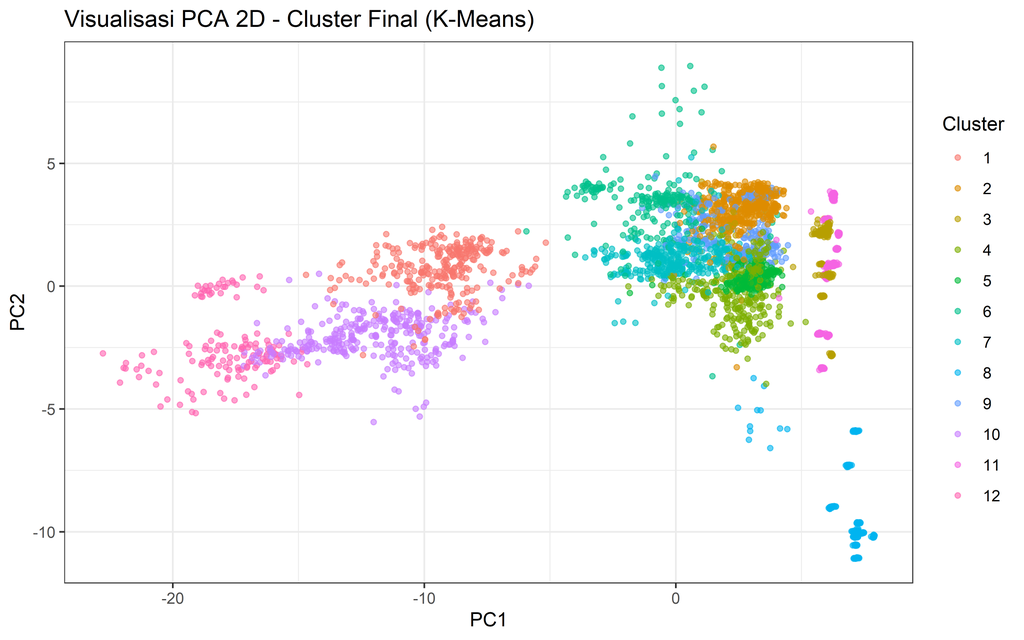

```r
pca_final_plot <- data.frame(
  PC1 = pca_data[, 1],
  PC2 = pca_data[, 2],
  Cluster_Final = window_features$Cluster_Final,
  Activity_Label = as.factor(window_features$activity_label),
  Subject = window_features$subject_id
)

ggplot(pca_final_plot, aes(x = PC1, y = PC2, color = Cluster_Final)) +
  geom_point(alpha = 0.6, size = 1.2) +
  labs(
    title = paste("Visualisasi PCA 2D - Cluster Final (", best_method, ")", sep = ""),
    x = "PC1",
    y = "PC2",
    color = "Cluster"
  ) +
  theme_bw()
```

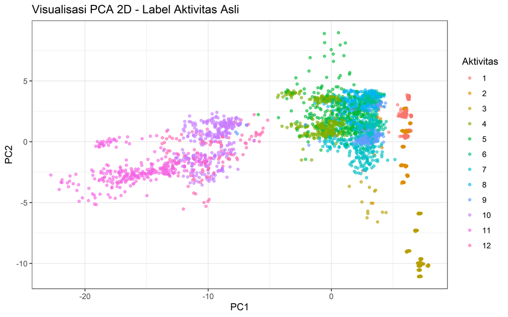

```r
ggplot(pca_final_plot, aes(x = PC1, y = PC2, color = Activity_Label)) +
  geom_point(alpha = 0.6, size = 1.2) +
  labs(
    title = "Visualisasi PCA 2D - Label Aktivitas Asli",
    x = "PC1",
    y = "PC2",
    color = "Aktivitas"
  ) +
  theme_bw()
```

**Interpretasi visualisasi akhir:** Plot cluster final memperlihatkan struktur hasil unsupervised learning pada ruang PCA dua dimensi, sedangkan plot label aktivitas asli digunakan sebagai pembanding. Area yang warnanya konsisten menunjukkan pemisahan pola sensor yang kuat. Area yang saling bertumpuk menunjukkan bahwa beberapa aktivitas memiliki pola sensor yang mirip atau bahwa informasi penting berada pada komponen PCA lain di luar PC1 dan PC2. Oleh karena itu, visualisasi 2D bersifat pendukung, sedangkan keputusan akhir tetap mengacu pada tabel validasi dan profiling cluster.

# 17 Profiling dan Interpretasi

Profiling dilakukan untuk memahami karakter setiap cluster. Karena data berasal dari sensor, interpretasi utama dilakukan melalui distribusi label aktivitas dominan pada setiap cluster dan distribusi subjek.

```r
cluster_size <- as.data.table(table(window_features$Cluster_Final))
setnames(cluster_size, c("Cluster_Final", "N"))
cluster_size[, Persentase := round(N / sum(N) * 100, 2)]

knitr::kable(
  cluster_size,
  caption = "Ukuran Cluster Final",
  format.args = list(big.mark = ",")
)
```

Ukuran Cluster Final

| Cluster_Final | N | Persentase |
| --- | --- | --- |
| 1 | 271 | 7.88 |
| 2 | 424 | 12.34 |
| 3 | 265 | 7.71 |
| 4 | 299 | 8.70 |
| 5 | 243 | 7.07 |
| 6 | 224 | 6.52 |
| 7 | 327 | 9.51 |
| 8 | 307 | 8.93 |
| 9 | 262 | 7.62 |
| 10 | 311 | 9.05 |
| 11 | 363 | 10.56 |
| 12 | 141 | 4.10 |

```r
activity_by_cluster <- window_features[, .N, by = .(Cluster_Final, activity_label)]
activity_by_cluster <- merge(activity_by_cluster, activity_map, by = "activity_label", all.x = TRUE)
activity_by_cluster[, Proporsi := round(N / sum(N) * 100, 2), by = Cluster_Final]

knitr::kable(
  activity_by_cluster[order(Cluster_Final, -N)],
  caption = "Distribusi Aktivitas pada Setiap Cluster",
  format.args = list(big.mark = ",")
)
```

Distribusi Aktivitas pada Setiap Cluster

| activity_label | Cluster_Final | N | activity_name | Proporsi |
| --- | --- | --- | --- | --- |
| 10 | 1 | 213 | Jogging | 78.60 |
| 12 | 1 | 53 | Jump front and back | 19.56 |
| 9 | 1 | 4 | Cycling | 1.48 |
| 11 | 1 | 1 | Running | 0.37 |
| 8 | 2 | 204 | Knees bending/crouching | 48.11 |
| 6 | 2 | 98 | Waist bends forward | 23.11 |
| 5 | 2 | 60 | Climbing stairs | 14.15 |
| 9 | 2 | 60 | Cycling | 14.15 |
| 2 | 2 | 1 | Sitting and relaxing | 0.24 |
| 3 | 2 | 1 | Lying down | 0.24 |
| 1 | 3 | 151 | Standing still | 56.98 |
| 2 | 3 | 90 | Sitting and relaxing | 33.96 |
| 5 | 3 | 21 | Climbing stairs | 7.92 |
| 8 | 3 | 3 | Knees bending/crouching | 1.13 |
| 7 | 4 | 294 | Frontal elevation of arms | 98.33 |
| 5 | 4 | 2 | Climbing stairs | 0.67 |
| 2 | 4 | 1 | Sitting and relaxing | 0.33 |
| 3 | 4 | 1 | Lying down | 0.33 |
| 6 | 4 | 1 | Waist bends forward | 0.33 |
| 9 | 5 | 242 | Cycling | 99.59 |
| 8 | 5 | 1 | Knees bending/crouching | 0.41 |
| 5 | 6 | 119 | Climbing stairs | 53.12 |
| 4 | 6 | 96 | Walking | 42.86 |
| 1 | 6 | 4 | Standing still | 1.79 |
| 8 | 6 | 2 | Knees bending/crouching | 0.89 |
| 2 | 6 | 1 | Sitting and relaxing | 0.45 |
| 3 | 6 | 1 | Lying down | 0.45 |
| 9 | 6 | 1 | Cycling | 0.45 |
| 4 | 7 | 214 | Walking | 65.44 |
| 5 | 7 | 89 | Climbing stairs | 27.22 |
| 8 | 7 | 24 | Knees bending/crouching | 7.34 |
| 3 | 8 | 306 | Lying down | 99.67 |
| 2 | 8 | 1 | Sitting and relaxing | 0.33 |
| 6 | 9 | 182 | Waist bends forward | 69.47 |
| 8 | 9 | 60 | Knees bending/crouching | 22.90 |
| 5 | 9 | 19 | Climbing stairs | 7.25 |
| 9 | 9 | 1 | Cycling | 0.38 |
| 11 | 10 | 166 | Running | 53.38 |
| 10 | 10 | 92 | Jogging | 29.58 |
| 12 | 10 | 53 | Jump front and back | 17.04 |
| 2 | 11 | 211 | Sitting and relaxing | 58.13 |
| 1 | 11 | 151 | Standing still | 41.60 |
| 5 | 11 | 1 | Climbing stairs | 0.28 |
| 11 | 12 | 140 | Running | 99.29 |
| 10 | 12 | 1 | Jogging | 0.71 |

```r
dominant_activity <- activity_by_cluster[order(Cluster_Final, -N), .SD[1], by = Cluster_Final]
knitr::kable(
  dominant_activity,
  caption = "Aktivitas Dominan pada Setiap Cluster",
  format.args = list(big.mark = ",")
)
```

Aktivitas Dominan pada Setiap Cluster

| Cluster_Final | activity_label | N | activity_name | Proporsi |
| --- | --- | --- | --- | --- |
| 1 | 10 | 213 | Jogging | 78.60 |
| 2 | 8 | 204 | Knees bending/crouching | 48.11 |
| 3 | 1 | 151 | Standing still | 56.98 |
| 4 | 7 | 294 | Frontal elevation of arms | 98.33 |
| 5 | 9 | 242 | Cycling | 99.59 |
| 6 | 5 | 119 | Climbing stairs | 53.12 |
| 7 | 4 | 214 | Walking | 65.44 |
| 8 | 3 | 306 | Lying down | 99.67 |
| 9 | 6 | 182 | Waist bends forward | 69.47 |
| 10 | 11 | 166 | Running | 53.38 |
| 11 | 2 | 211 | Sitting and relaxing | 58.13 |
| 12 | 11 | 140 | Running | 99.29 |

```r
subject_cluster <- as.data.table(table(window_features$Cluster_Final, window_features$subject_id))
setnames(subject_cluster, c("Cluster_Final", "Subject", "N"))

knitr::kable(
  subject_cluster[order(Cluster_Final, Subject)],
  caption = "Distribusi Subjek pada Setiap Cluster",
  format.args = list(big.mark = ",")
)
```

Distribusi Subjek pada Setiap Cluster

| Cluster_Final | Subject | N |
| --- | --- | --- |
| 1 | 1 | 0 |
| 1 | 10 | 41 |
| 1 | 2 | 11 |
| 1 | 3 | 41 |
| 1 | 4 | 31 |
| 1 | 5 | 31 |
| 1 | 6 | 2 |
| 1 | 7 | 30 |
| 1 | 8 | 42 |
| 1 | 9 | 42 |
| 10 | 1 | 41 |
| 10 | 10 | 31 |
| 10 | 2 | 61 |
| 10 | 3 | 10 |
| 10 | 4 | 42 |
| 10 | 5 | 11 |
| 10 | 6 | 42 |
| 10 | 7 | 42 |
| 10 | 8 | 0 |
| 10 | 9 | 31 |
| 11 | 1 | 61 |
| 11 | 10 | 31 |
| 11 | 2 | 61 |
| 11 | 3 | 29 |
| 11 | 4 | 30 |
| 11 | 5 | 30 |
| 11 | 6 | 30 |
| 11 | 7 | 61 |
| 11 | 8 | 30 |
| 11 | 9 | 0 |

[output cut: 90 more lines]

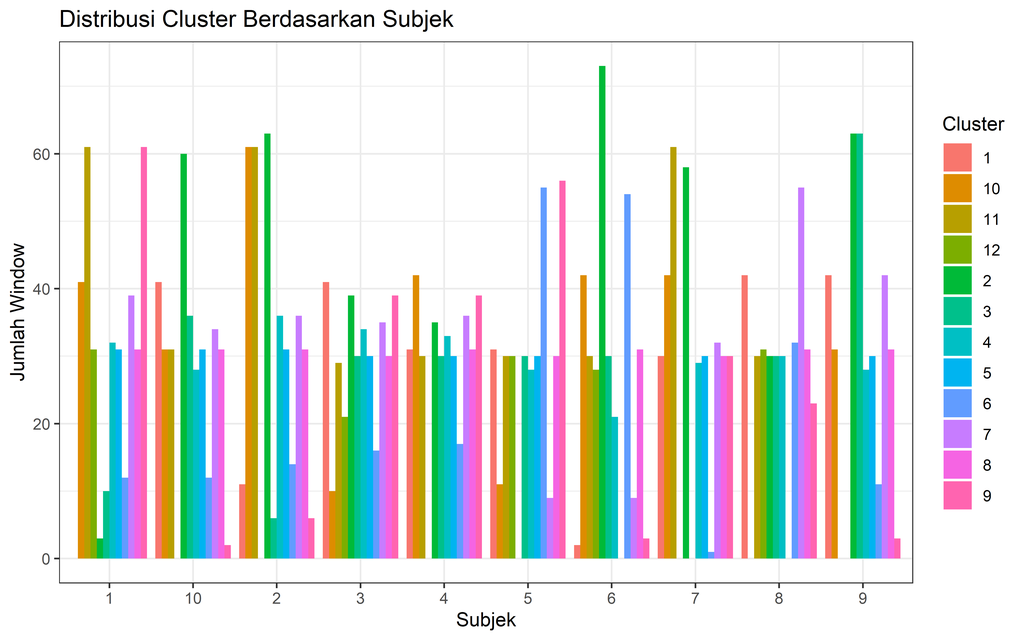

```r
ggplot(subject_cluster, aes(x = Subject, y = N, fill = Cluster_Final)) +
  geom_col(position = "dodge") +
  labs(
    title = "Distribusi Cluster Berdasarkan Subjek",
    x = "Subjek",
    y = "Jumlah Window",
    fill = "Cluster"
  ) +
  theme_bw()
```

**Interpretasi distribusi subjek:** Tidak ada cluster yang sangat didominasi oleh satu subjek. Ini mengindikasikan bahwa cluster lebih mungkin merepresentasikan pola aktivitas/sensor umum daripada hanya karakteristik individu tertentu.

```r
cat("## Interpretasi Ringkas Cluster\n\n")
```

## 17.1 Interpretasi Ringkas Cluster

```r
for (i in seq_len(nrow(dominant_activity))) {
  cl <- dominant_activity$Cluster_Final[i]
  act <- dominant_activity$activity_name[i]
  prop <- dominant_activity$Proporsi[i]
  n_cluster <- cluster_size$N[cluster_size$Cluster_Final == cl]

  cat("### Cluster ", cl, "\n\n", sep = "")
  cat("Cluster ini berisi **", scales::comma(n_cluster), " window**. ", sep = "")
  cat("Aktivitas yang paling dominan pada cluster ini adalah **", act, "** ", sep = "")
  cat("dengan proporsi sekitar **", prop, "%** dari seluruh window pada cluster tersebut.\n\n", sep = "")

  if (prop >= 70) {
    cat("Interpretasi: cluster ini relatif homogen dan cukup kuat merepresentasikan aktivitas tersebut.\n\n")
  } else if (prop >= 40) {
    cat("Interpretasi: cluster ini cukup berkaitan dengan aktivitas dominan, tetapi masih bercampur dengan aktivitas lain.\n\n")
  } else {
    cat("Interpretasi: cluster ini masih heterogen sehingga kemungkinan merepresentasikan pola sensor gabungan, transisi, atau variasi antar subjek.\n\n")
  }
}
```

### 17.1.1 Cluster 1

Cluster ini berisi **271 window**. Aktivitas yang paling dominan pada cluster ini adalah **Jogging** dengan proporsi sekitar **78.6%** dari seluruh window pada cluster tersebut.

Interpretasi: cluster ini relatif homogen dan cukup kuat merepresentasikan aktivitas tersebut.

### 17.1.2 Cluster 2

Cluster ini berisi **424 window**. Aktivitas yang paling dominan pada cluster ini adalah **Knees bending/crouching** dengan proporsi sekitar **48.11%** dari seluruh window pada cluster tersebut.

Interpretasi: cluster ini cukup berkaitan dengan aktivitas dominan, tetapi masih bercampur dengan aktivitas lain.

### 17.1.3 Cluster 3

Cluster ini berisi **265 window**. Aktivitas yang paling dominan pada cluster ini adalah **Standing still** dengan proporsi sekitar **56.98%** dari seluruh window pada cluster tersebut.

Interpretasi: cluster ini cukup berkaitan dengan aktivitas dominan, tetapi masih bercampur dengan aktivitas lain.

### 17.1.4 Cluster 4

Cluster ini berisi **299 window**. Aktivitas yang paling dominan pada cluster ini adalah **Frontal elevation of arms** dengan proporsi sekitar **98.33%** dari seluruh window pada cluster tersebut.

Interpretasi: cluster ini relatif homogen dan cukup kuat merepresentasikan aktivitas tersebut.

### 17.1.5 Cluster 5

Cluster ini berisi **243 window**. Aktivitas yang paling dominan pada cluster ini adalah **Cycling** dengan proporsi sekitar **99.59%** dari seluruh window pada cluster tersebut.

Interpretasi: cluster ini relatif homogen dan cukup kuat merepresentasikan aktivitas tersebut.

### 17.1.6 Cluster 6

Cluster ini berisi **224 window**. Aktivitas yang paling dominan pada cluster ini adalah **Climbing stairs** dengan proporsi sekitar **53.12%** dari seluruh window pada cluster tersebut.

Interpretasi: cluster ini cukup berkaitan dengan aktivitas dominan, tetapi masih bercampur dengan aktivitas lain.

### 17.1.7 Cluster 7

Cluster ini berisi **327 window**. Aktivitas yang paling dominan pada cluster ini adalah **Walking** dengan proporsi sekitar **65.44%** dari seluruh window pada cluster tersebut.

Interpretasi: cluster ini cukup berkaitan dengan aktivitas dominan, tetapi masih bercampur dengan aktivitas lain.

### 17.1.8 Cluster 8

Cluster ini berisi **307 window**. Aktivitas yang paling dominan pada cluster ini adalah **Lying down** dengan proporsi sekitar **99.67%** dari seluruh window pada cluster tersebut.

Interpretasi: cluster ini relatif homogen dan cukup kuat merepresentasikan aktivitas tersebut.

### 17.1.9 Cluster 9

Cluster ini berisi **262 window**. Aktivitas yang paling dominan pada cluster ini adalah **Waist bends forward** dengan proporsi sekitar **69.47%** dari seluruh window pada cluster tersebut.

Interpretasi: cluster ini cukup berkaitan dengan aktivitas dominan, tetapi masih bercampur dengan aktivitas lain.

### 17.1.10 Cluster 10

Cluster ini berisi **311 window**. Aktivitas yang paling dominan pada cluster ini adalah **Running** dengan proporsi sekitar **53.38%** dari seluruh window pada cluster tersebut.

Interpretasi: cluster ini cukup berkaitan dengan aktivitas dominan, tetapi masih bercampur dengan aktivitas lain.

### 17.1.11 Cluster 11

Cluster ini berisi **363 window**. Aktivitas yang paling dominan pada cluster ini adalah **Sitting and relaxing** dengan proporsi sekitar **58.13%** dari seluruh window pada cluster tersebut.

Interpretasi: cluster ini cukup berkaitan dengan aktivitas dominan, tetapi masih bercampur dengan aktivitas lain.

### 17.1.12 Cluster 12

Cluster ini berisi **141 window**. Aktivitas yang paling dominan pada cluster ini adalah **Running** dengan proporsi sekitar **99.29%** dari seluruh window pada cluster tersebut.

Interpretasi: cluster ini relatif homogen dan cukup kuat merepresentasikan aktivitas tersebut.

# 18 Simpan Output

Hasil akhir disimpan agar dapat digunakan kembali tanpa mengulang seluruh proses preprocessing dan clustering.

```r
data.table::fwrite(window_features, "mhealth_window_features_with_clusters.csv")
data.table::fwrite(validasi_gabungan, "mhealth_cluster_validation_summary.csv")

cat("File berhasil disimpan:\n")
```

```
## File berhasil disimpan:
```

```r
cat("1. mhealth_window_features_with_clusters.csv\n")
```

```
## 1. mhealth_window_features_with_clusters.csv
```

```r
cat("2. mhealth_cluster_validation_summary.csv\n")
```

```
## 2. mhealth_cluster_validation_summary.csv
```

# 19 Kesimpulan

Analisis ini menunjukkan bahwa dataset MHEALTH dapat digunakan untuk unsupervised learning dan clustering, tetapi perlu diproses secara khusus karena merupakan data time-series sensor. Data mentah terlebih dahulu diubah menjadi fitur berbasis window, kemudian distandarisasi, direduksi dimensinya menggunakan PCA, dan dianalisis menggunakan beberapa metode clustering.

Metode yang dibandingkan meliputi K-Means, Gaussian Mixture Model, Hierarchical Clustering dengan average linkage, PAM/K-Medoids, dan DBSCAN. Validasi dilakukan menggunakan internal criteria dan external criteria. Label aktivitas hanya digunakan untuk evaluasi akhir, bukan sebagai input clustering.